# **第五章: 非约束性排序 – Unconstrained Ordination**

本章内容简介:

- 5.1 目的
- 5.2 排序方法简介
- 5.3 主成分分析 - Principal Component Analysis (PCA)
- 5.4 对应分析 - Correspondence Analysis (CA)
- 5.5 主坐标分析 - Principal Coordinate Analysis (PCoA)
- 5.6 非度量多维尺度分析 - Nonmetric Multidimensional Scaling (NMDS)
- 5.7 手写 PCA 排序函数

## 5.1 目的

聚类分析查找数据集中的**不连续性**, 排序分析以连续轴的形式**提取主要趋势**. **排序方法**适用于对**自然生态群落数据集**(结构呈现**梯度**形式)进行分析.

- 正确选择排序方法, 对排序结果进行解读
- 应用排序方法分析河流数据集和甲螨数据集
- 排序结果叠加聚类分析的结果并加以解释
- 使用外部数据集中的环境变量解释物种数据集排序分析的结构
- 编写 PCA 函数

## 5.2 排序方法简介

### 5.2.1 多维度空间 - Multidimensional Space

多变量数据集可被视为位于空间中的位点集合, 其中每个变量定义一个维度. 通过位点的散点图揭示数据的结构. 由于生态数据通常包含两个以上的变量, 因此绘制所有可能变量关系对的散点图十分繁琐 且所含信息量不大. (所有可能变量关系对的数量 – 数学中的**组合** – n*(n-1)/2 )

排序方法的目的是沿着减少数量的正交轴表示数据, 即它们以递减的顺序表示数据变化的主要趋势, 可以通过可视化关联解释分析结果. 本章介绍的所有排序分析方法都是**描述性**的, 没有提供统计检验来评估结果的显著性. 第六章所介绍的**约束性排序**将提供**统计检验**方法.

### 5.2.2 降维排序 - Ordination in Reduced Space

大多数排序方法(除 **NMDS** 之外)都是基于提取相关性矩阵中的特征值进行后续的分析. 根据位点间的相异度差别以及变量类别进行分类.

排序分析中的基本原则如下: *n* 个对象 & *p* 个变量; 在 *p*-维空间中, *n* 个对象可以表示为一个点簇(聚类), 该聚类结果并非圆形, 而是偏平的椭圆形(在一些维度上被拉伸, 在另一些维度上被压平); 经过变化的方向不一定与多维空间的单个维度（单个变量）对齐. **簇最长的方向对应于簇的最大方差的方向**. 最大方差的方向对应于数据中存在的最强梯度: 这是最重要信息所在的位置. 要提取的下一个轴在方差中是第二重要的, 只要它与第一个轴正交(线性无关, 标量积为0). 该过程继续, 直到计算出所有轴.

当数据中存在一些主要结构(梯度或组)并且该方法在提取时是有效的, 那么第一轴包含大部分有用信息(提取了数据的大部分**方差**). 在这种情况下, (降维空间)缩小空间(最常见的是二维)**投影**中**位点**之间的距离与多维空间中的对象之间的距离相对类似. *即使第一轴占方差的一小部分, 排序也很有用.* 当在其他噪声数据集中存在一些有趣的结构时, 这可能发生 *第一轴占方差的一小部分* 这种情况. **==>>** **应该保留和解释多少轴? 有多少轴代表可解释的结构?** ==>> **取决于 方法和数据** – 视具体情况而定

本章介绍的方法如下:

- Principal component analysis (PCA): 主成分分析 – 基于特征向量的方法, 对**原始定量数据**进行分析; scaling 1 – 保留位点之间的 Euclidean 距离, scaling 2 – 保留位点之间的 Mahalanobis 距离.
- Correspondence analysis (CA): 对应分析 – 所处理的数据必须是**非负+维度均质化+频率或者类频率**类型的数据; scaling 1 – 行方向保留 χ2 (卡方) 距离, scaling 2 – 列方向保留 χ2 (卡方) 距离. 在生态学中, 几乎可以完全应用于**群落组成型数据**分析.
- Multiple correspondence analysis (MCA): 多元对应分析 – 类别变量列表的排序, 所有的变量因子化.
- Principal coordinate analysis (PCoA): 主坐标分析 – Q 模式下, 对相异矩阵进行排序分析, 并不是对逐个变量表进行分析; 关联方法的选择上具有更高的灵活性.
- Nonmetric multidimensional scaling (NMDS): 非度量多维尺度分析 – 与上述几种方法不同, 不依赖于特征向量. 沿预定数量的轴表示对象集合, 同时保留它们之间的排序关系. 对相异性矩阵进行运算.

PCoA & NMDS 可对任何 *平方相异性矩阵* 进行排序.

## 5.3 主成分分析 - Principal Component Analysis (PCA)

### 5.3.1 主成分分析简介 (PCA)

多元正态分布矩阵(每个变量都是正态分布的).

第一主轴(或主分量轴)是穿过该多元正态分布的浓度椭球的最大维度的直线(拥有方差的最大部分); 其余的轴线彼此正交并且相继较短. *(椭圆体, 轴线有长有短)* 对于含有 *p* 个变量的矩阵最多含有 *p* 个主成分.

PCA 对由变量所定义的原始轴系统进行旋转, 使得连续的新轴(主成分)相互正交, 且所获得的连续新轴(主成分)对应着 *散点* 最大方差的连续维度. 主成分给出了新坐标系统中对象的位置.

主成分分析的输入数据为 **方差矩阵** (比如包含维度均质化变量的方差和协方差的关联矩阵, 或者由维度异质性变量计算而来的相关性矩阵). PCA专门用于定量变量数据的分析. 相异性矩阵 – Euclidean 距离计算, 变量之间线性相关关系. 不适用与 **原始物种丰度数据** 的分析. 但可以对 **原始物种丰度数据** 进行 **数据预转换** 处理之后再进行主成分分析.

PCA的排序结果仍遵循笛卡尔坐标系系统(Cartesian coordinate), 对象 – 点, 变量 – 箭头.

vegan – rda(); ade4 – dudi.pca(); stats – prcomp(); 本书中的自备函数 PCA.newr()

### 5.3.2 使用 rda() 对河流数据集的环境变量进行主成分分析

对河流数据集中的 11 个定量环境变量进行分析, 分析不同环境变量之间的关联性如何以及从位点的排序分析中可以获得哪些信息.

由于不同的环境变量采用了不同的测量标度(维度异质性), 因此需要首先获得相关性矩阵(标准化变量的协方差), 然后在进行主成分分析.

#### 5.3.2.1 数据的预处理

```r
# 解决警告信息的显示问题
# Warning: Input string not available in this locale
Sys.setlocale('LC_ALL','C')
```

```
## [1] "C"
```

```r
# 导入分析包
# ade4 https://www.rdocumentation.org/packages/ade4/versions/1.7-13
# 生态型数据分析(多变量数据分析): 环境科学中的探索分析和 Euclidean 方法
# vegan https://www.rdocumentation.org/packages/vegan/versions/2.4-2
# 群落生态分析包: 排序方法, 多样性分析等
# gclus https://www.rdocumentation.org/packages/gclus/versions/1.3.2
# 聚类图形: 排序面板信息等
# ape https://www.rdocumentation.org/packages/ape/versions/5.3
# 系统发育与进化分析
# missMDA https://www.rdocumentation.org/packages/missMDA/versions/1.14
# 处理多变量数据分析处理缺失值
# FactoMineR https://www.rdocumentation.org/packages/FactoMineR/versions/1.41
# 多变量探索性分析和数据挖掘
library(ade4)
library(vegan) # 后期会重点解读该包的总和使用
library(gclus)
library(ape)
library(missMDA)
library(FactoMineR)
```

```r
# 导入分析脚本和数据集
source("Functions/cleanplot.pca.R")
source("Functions/PCA.newr.R")
source("Functions/CA.newr.R")
load("Data/mite.RData")
load("Data/Doubs.RData")
# 移除第八列数据, 列名代表位点
spe <- spe[-8, ]
env <- env[-8, ]
spa <- spa[-8, ]
```

#### 5.3.2.2 相关性矩阵的主成分分析 (PCA)

```r
summary(env)
```

```
##       dfs             ele             slo              dis
##  Min.   :  0.3   Min.   :172.0   Min.   : 0.200   Min.   : 0.84
##  1st Qu.: 70.5   1st Qu.:246.0   1st Qu.: 0.500   1st Qu.: 4.80
##  Median :185.9   Median :375.0   Median : 1.200   Median :23.00
##  Mean   :193.0   Mean   :470.9   Mean   : 3.531   Mean   :22.92
##  3rd Qu.:304.3   3rd Qu.:752.0   3rd Qu.: 3.000   3rd Qu.:28.80
##  Max.   :453.0   Max.   :934.0   Max.   :48.000   Max.   :69.00
##        pH             har              pho            nit
##  Min.   :7.700   Min.   : 40.00   Min.   :0.01   Min.   :0.150
##  1st Qu.:7.900   1st Qu.: 84.00   1st Qu.:0.10   1st Qu.:0.520
##  Median :8.000   Median : 88.00   Median :0.30   Median :1.600
##  Mean   :8.048   Mean   : 85.83   Mean   :0.57   Mean   :1.697
##  3rd Qu.:8.100   3rd Qu.: 97.00   3rd Qu.:0.58   3rd Qu.:2.500
##  Max.   :8.600   Max.   :110.00   Max.   :4.22   Max.   :6.200
##       amm              oxy              bod
##  Min.   :0.0000   Min.   : 4.100   Min.   : 1.300
##  1st Qu.:0.0000   1st Qu.: 8.100   1st Qu.: 2.700
##  Median :0.1000   Median :10.200   Median : 4.100
##  Mean   :0.2124   Mean   : 9.472   Mean   : 5.014
##  3rd Qu.:0.2000   3rd Qu.:11.000   3rd Qu.: 5.200
##  Max.   :1.8000   Max.   :12.400   Max.   :16.700
```

```r
# 结果中的 Inertia -- 变量数量 | 惯性, 惯量
# 1> 协方差矩阵的PCA分析结果中变量总方差 2> 相关性矩阵的PCA分析结果中对角线的数值和 = 变量自相关系数的总和 = 变量的数量
# 结果中的 Unconstrained -- PCA - 非约束性排序
# 结果中的 Eigenvalues -- 特征值 - PCA轴的重要性(方差)的度量 -可以表示为比例解释, 或轴的变化比例, 通过将每个特征值除以"总惯量"
(env.pca <- rda(env, # 环境变量数据
                scale = TRUE)) #对变量进行标准化
```

```
## Call: rda(X = env, scale = TRUE)
##
##               Inertia Rank
## Total              11
## Unconstrained      11   11
## Inertia is correlations
##
## Eigenvalues for unconstrained axes:
##   PC1   PC2   PC3   PC4   PC5   PC6   PC7   PC8   PC9  PC10  PC11
## 6.098 2.167 1.038 0.704 0.352 0.319 0.165 0.112 0.023 0.017 0.006
```

```r
# Scaling -- 不要与 变量标准化 中的 "scale" 相混淆; 这里特指 排序结果投影到降维空间的图形展示方式;
# 最优化展示 对象和变量 没有简单的方法
# 默认 scaling = 2 -- correlation biplot -- 相关性双序图; 特征向量被标准化为特征值的平方根;
# 1> 双序图中 对象之间的距离 不近似于 多维孔空间中的 欧式距离, 2> 向量之间的角度反映相关性
# 物种得分: 变量箭头的坐标. "物种" 源于 分析包 vegan 使用的历史因素
# 位点得分: 排序结果中位点的坐标. 对象 通常被称为 位点
summary(env.pca)
```

```
##
## Call:
## rda(X = env, scale = TRUE)
##
## Partitioning of correlations:
##               Inertia Proportion
## Total              11          1
## Unconstrained      11          1
##
## Eigenvalues, and their contribution to the correlations
##
## Importance of components:
##                          PC1    PC2     PC3     PC4     PC5     PC6
## Eigenvalue            6.0979 2.1672 1.03761 0.70353 0.35174 0.31912
## Proportion Explained  0.5544 0.1970 0.09433 0.06396 0.03198 0.02901
## Cumulative Proportion 0.5544 0.7514 0.84571 0.90967 0.94164 0.97065
##                           PC7     PC8      PC9    PC10      PC11
## Eigenvalue            0.16453 0.11173 0.023134 0.01737 0.0060521
## Proportion Explained  0.01496 0.01016 0.002103 0.00158 0.0005502
## Cumulative Proportion 0.98561 0.99577 0.997870 0.99945 1.0000000
##
## Scaling 2 for species and site scores
## * Species are scaled proportional to eigenvalues
## * Sites are unscaled: weighted dispersion equal on all dimensions
## * General scaling constant of scores:  4.189264
##
##
## Species scores
##
##         PC1     PC2      PC3      PC4      PC5      PC6
## dfs  1.0842  0.5150 -0.25749 -0.16168  0.21132 -0.09485
## ele -1.0437 -0.5945  0.17984  0.12282  0.12464  0.14022
## slo -0.5752 -0.5103 -0.55499 -0.80204  0.02764  0.20077
## dis  0.9577  0.6412 -0.30654 -0.19427  0.18401  0.03068
## pH  -0.0586  0.4820  1.03444 -0.51378  0.14421  0.05821
## har  0.9072  0.6181 -0.02280  0.15767 -0.27865  0.50738
## pho  1.0460 -0.6093  0.18734 -0.11866 -0.15113  0.04888
## nit  1.1432 -0.1290  0.01203 -0.18471 -0.21270 -0.34907
## amm  0.9954 -0.6989  0.18597 -0.08277 -0.19234 -0.04979
## oxy -1.0089  0.4578 -0.00918 -0.23450 -0.50552 -0.05764
```

[output cut: 20 more lines]

```
## 16 -0.14329  0.31112 -0.21270  0.24363 -0.61744 -0.52902
## 17  0.08956  0.29836 -0.18601  0.23428 -0.73164 -0.44261
## 18  0.05649  0.34914 -0.22049  0.14198 -0.76039 -0.60408
## 19  0.04513  0.40790  0.12272 -0.20091 -0.49665 -0.87755
## 20  0.16126  0.36126 -0.28796 -0.05345 -0.79294 -1.36200
## 21  0.16079  0.32644 -0.74873  0.40912  0.17568 -0.90766
## 22  0.14178  0.53551 -0.08106 -0.07021  0.58856 -0.24654
## 23  1.37614 -1.19047  0.74766 -0.35075 -0.22921  0.75808
## 24  0.98260 -0.51434  0.01123  0.40978  1.01197  0.84836
## 25  2.18633 -2.04860  0.35017 -0.29583 -1.26009 -0.39052
## 26  0.88257 -0.11921 -0.64734  0.34001  0.85793 -0.14280
## 27  0.63983  0.39438 -0.15997 -0.30089  1.09889 -0.66497
## 28  0.75833  0.80559  0.51015 -0.96863  0.42032 -0.74305
## 29  0.65324  1.09406 -1.68227  0.37796  0.43707  0.65309
## 30  0.73849  1.36252 -0.27161 -0.62819  1.42387  0.88211
```

```r
# distance biplot -- 距离双序图: 特征向量被标准化为单位向量;
# 1> 双序图中 对象之间的距离 近似于 多维孔空间中的 欧式距离, 2> 向量之间的角度不反映之间的相关性
summary(env.pca, scaling = 1)
```

```
##
## Call:
## rda(X = env, scale = TRUE)
##
## Partitioning of correlations:
##               Inertia Proportion
## Total              11          1
## Unconstrained      11          1
##
## Eigenvalues, and their contribution to the correlations
##
## Importance of components:
##                          PC1    PC2     PC3     PC4     PC5     PC6
## Eigenvalue            6.0979 2.1672 1.03761 0.70353 0.35174 0.31912
## Proportion Explained  0.5544 0.1970 0.09433 0.06396 0.03198 0.02901
## Cumulative Proportion 0.5544 0.7514 0.84571 0.90967 0.94164 0.97065
##                           PC7     PC8      PC9    PC10      PC11
## Eigenvalue            0.16453 0.11173 0.023134 0.01737 0.0060521
## Proportion Explained  0.01496 0.01016 0.002103 0.00158 0.0005502
## Cumulative Proportion 0.98561 0.99577 0.997870 0.99945 1.0000000
##
## Scaling 1 for species and site scores
## * Sites are scaled proportional to eigenvalues
## * Species are unscaled: weighted dispersion equal on all dimensions
## * General scaling constant of scores:  4.189264
##
##
## Species scores
##
##          PC1     PC2      PC3     PC4     PC5     PC6
## dfs  1.45620  1.1603 -0.83838 -0.6393  1.1817 -0.5569
## ele -1.40176 -1.3393  0.58556  0.4856  0.6970  0.8233
## slo -0.77256 -1.1498 -1.80704 -3.1714  0.1546  1.1787
## dis  1.28627  1.4446 -0.99809 -0.7682  1.0290  0.1801
## pH  -0.07871  1.0858  3.36812 -2.0316  0.8064  0.3418
## har  1.21849  1.3925 -0.07423  0.6235 -1.5583  2.9789
## pho  1.40489 -1.3726  0.60999 -0.4692 -0.8452  0.2870
## nit  1.53537 -0.2907  0.03918 -0.7304 -1.1895 -2.0494
## amm  1.33691 -1.5745  0.60552 -0.3273 -1.0756 -0.2923
## oxy -1.35509  1.0314 -0.02989 -0.9273 -2.8270 -0.3384
```

[output cut: 20 more lines]

```
## 16 -0.10669  0.13810 -0.065325  0.06161 -0.11041 -0.09011
## 17  0.06668  0.13243 -0.057128  0.05925 -0.13083 -0.07539
## 18  0.04206  0.15497 -0.067718  0.03591 -0.13597 -0.10289
## 19  0.03360  0.18106  0.037690 -0.05081 -0.08881 -0.14947
## 20  0.12007  0.16035 -0.088441 -0.01352 -0.14179 -0.23199
## 21  0.11972  0.14490 -0.229955  0.10347  0.03141 -0.15460
## 22  0.10556  0.23770 -0.024895 -0.01776  0.10525 -0.04199
## 23  1.02461 -0.52841  0.229627 -0.08870 -0.04099  0.12912
## 24  0.73160 -0.22830  0.003449  0.10363  0.18096  0.14450
## 25  1.62784 -0.90932  0.107547 -0.07481 -0.22533 -0.06652
## 26  0.65712 -0.05291 -0.198815  0.08599  0.15341 -0.02432
## 27  0.47639  0.17505 -0.049132 -0.07609  0.19650 -0.11326
## 28  0.56462  0.35758  0.156683 -0.24496  0.07516 -0.12656
## 29  0.48638  0.48562 -0.516671  0.09558  0.07816  0.11124
## 30  0.54984  0.60478 -0.083419 -0.15887  0.25461  0.15025
```

```r
summary(env.pca, scaling = 1, axes = 0) # 不查看物种得分和位点得分
```

```
##
## Call:
## rda(X = env, scale = TRUE)
##
## Partitioning of correlations:
##               Inertia Proportion
## Total              11          1
## Unconstrained      11          1
##
## Eigenvalues, and their contribution to the correlations
##
## Importance of components:
##                          PC1    PC2     PC3     PC4     PC5     PC6
## Eigenvalue            6.0979 2.1672 1.03761 0.70353 0.35174 0.31912
## Proportion Explained  0.5544 0.1970 0.09433 0.06396 0.03198 0.02901
## Cumulative Proportion 0.5544 0.7514 0.84571 0.90967 0.94164 0.97065
##                           PC7     PC8      PC9    PC10      PC11
## Eigenvalue            0.16453 0.11173 0.023134 0.01737 0.0060521
## Proportion Explained  0.01496 0.01016 0.002103 0.00158 0.0005502
## Cumulative Proportion 0.98561 0.99577 0.997870 0.99945 1.0000000
##
## Scaling 1 for species and site scores
## * Sites are scaled proportional to eigenvalues
## * Species are unscaled: weighted dispersion equal on all dimensions
## * General scaling constant of scores:
```

> 如果解释**对象**之间的相互关系 ==>> scaling = 1 ; 如果解释**变量**之间的相互关系 ==>> scaling = 2
- scaling = 3 – 折中标度 - 对称标度 – 通过特征值的平方根来缩放位点和物种得分; 这种方案没有明确的解释规则, 不在本书中讨论

#### 5.3.2.3 对 vegan 分析包的输出结果进行信息提取,解释和可视化

**排序轴** 数量的选择 – 可解释 & 有意义

PCA – 不是统计检验分析, 但是一种 **启发式分析** - 在降维空间空间中展示数据的主要特征; 通常, 应先检验特征值, 然后确定展示的轴(主成分)的数量. 轴数量的选择比较随意, 解释大于 75% 的方差, 或者依据其他的判断标准. 比如, 计算断棒模型(broken stick model) – 它将单位长度的一根棍子随机分成与PCA特征值相同数量的碎片; 断棒模型的理论方程已知; 然后将这些片段按长度递减的顺序排列, 并与特征值进行比较; 只解释特征值大于棍子相应部分长度的轴.

```r
# ?cca.object # 约束排序的结果
(ev <- env.pca$CA$eig) # 查看特征值 - Eigenvalues
```

```
##         PC1         PC2         PC3         PC4         PC5         PC6
## 6.097948465 2.167241207 1.037605073 0.703525467 0.351737563 0.319124654
##         PC7         PC8         PC9        PC10        PC11
## 0.164529826 0.111727323 0.023133745 0.017374555 0.006052124
```

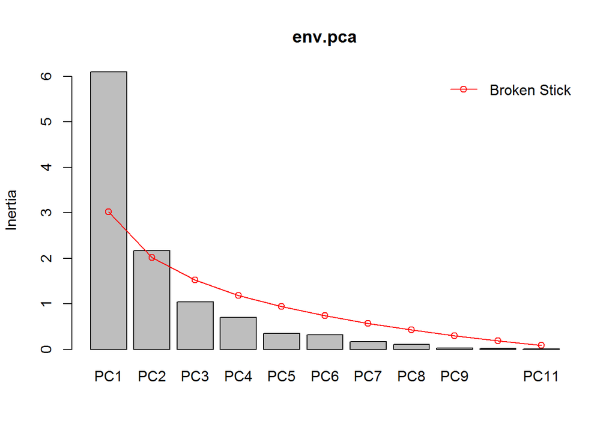

```r
# 绘制与主成分数量的差异
# https://www.rdocumentation.org/packages/stats/versions/3.6.0/topics/screeplot
screeplot(env.pca, bstick = TRUE, npcs = length(env.pca$CA$eig))
```

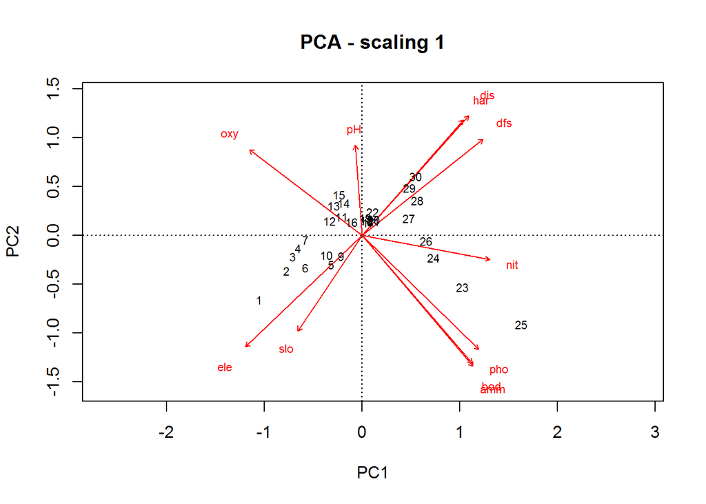

```r
# 绘制双序图
# http://biol09.biol.umontreal.ca/PLcourses/Ordination_section_1.1_PCA_Eng.pdf
# Scaling type 1: distance biplot
# Scaling type 2: correlation biplot,
biplot(env.pca,
       scaling = 1,
       main = "PCA - scaling 1")
```

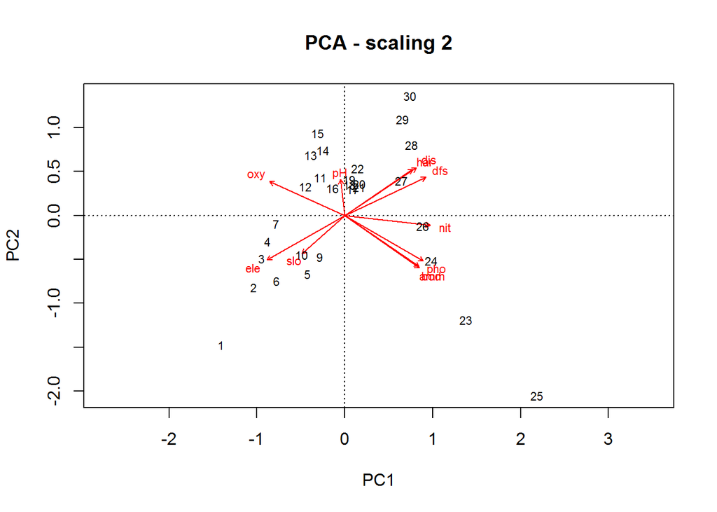

```r
biplot(env.pca,
       main = "PCA - scaling 2")
```

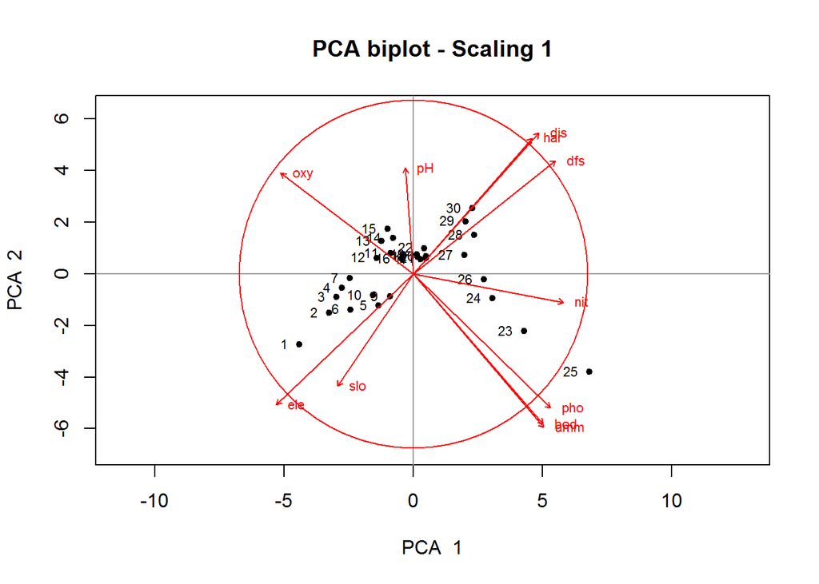

```r
# 需要矩形窗口来进行绘制
# par(mfrow = c(1, 2))
cleanplot.pca(env.pca,
              scaling = 1,
              mar.percent = 0.08)
```

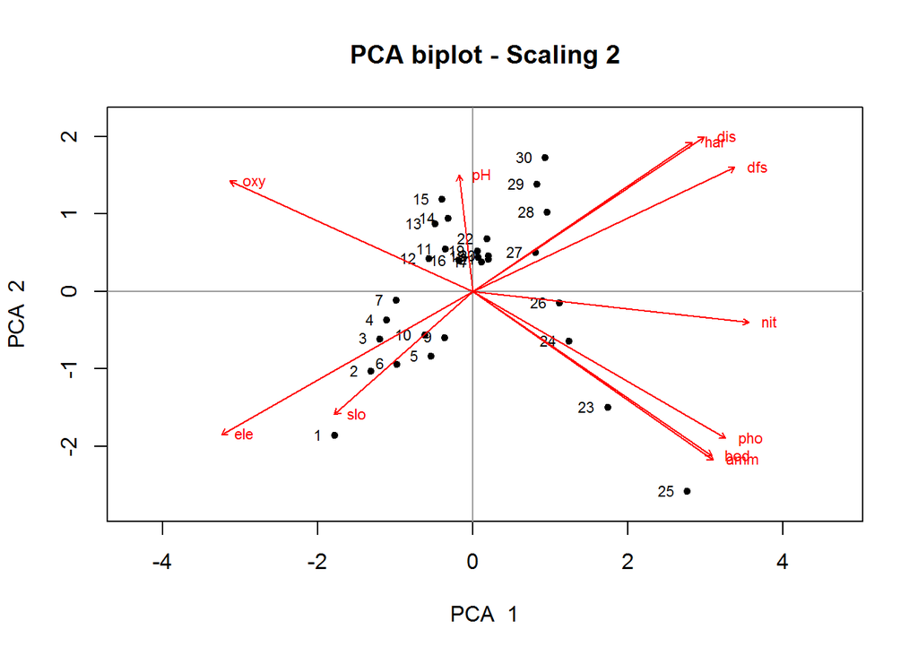

```r
cleanplot.pca(env.pca,
              scaling = 2,
              mar.percent = 0.04)
```

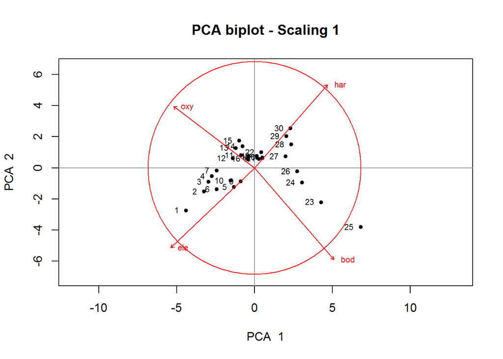

```r
# 绘制带变量子集的图: ele, oxy, har, bod
# par(mfrow = c(1, 2))
var.subset <- c(2, 6, 10, 11)
cleanplot.pca(
  env.pca,
  scaling = 1, # scaling = "sites" for scaling 1
  select.spe = var.subset,
  mar.percent = 0.10
  )
```

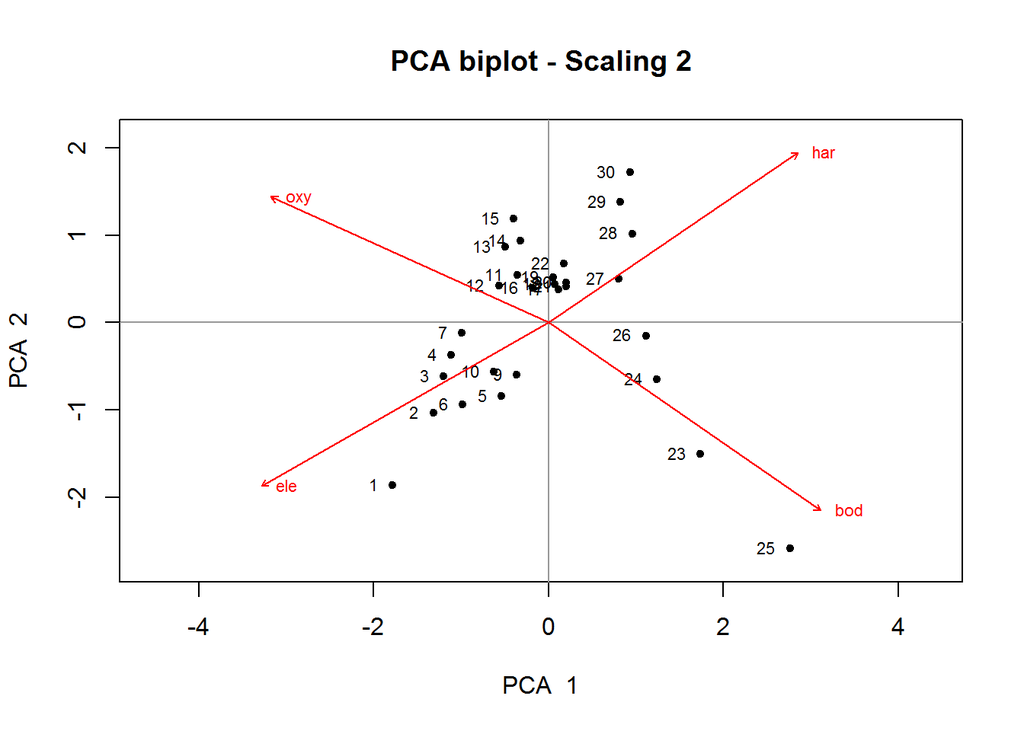

```r
cleanplot.pca(
  env.pca,
  scaling = 2, # scaling = "species" for scaling 2
  select.spe = var.subset,
  mar.percent = 0.04
  )
```

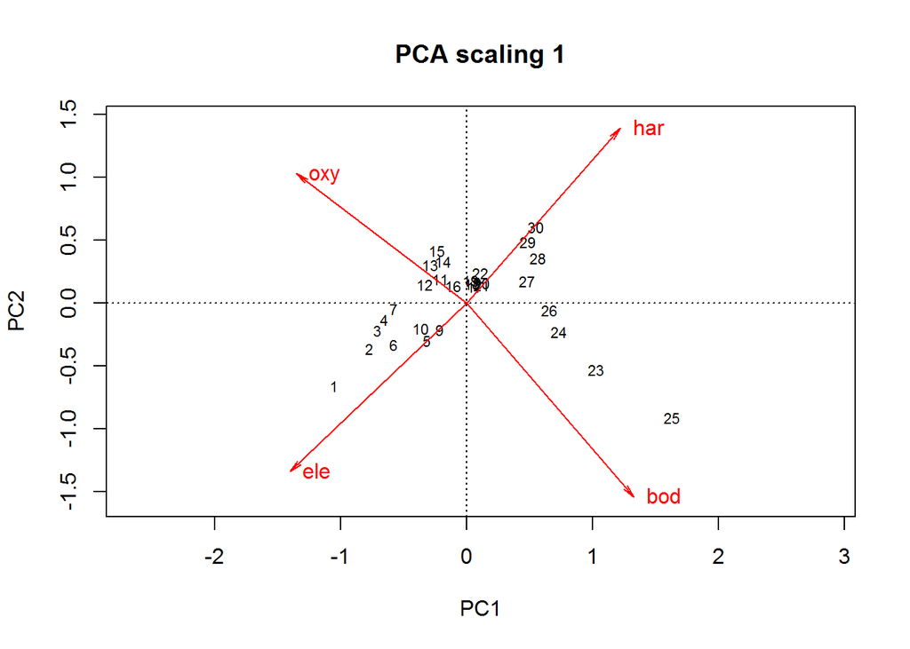

```r
# 使用 biplot() 绘制变量的子集: ele, oxy, har, bod,
# 圆圈 -- 平衡贡献圆
# 半径 --  sqrt(d/p)
# d -- number of axes represented in the biplot (usually d = 2)
# p -- number of dimensions of the PCA space (usually the number of variables of the data matrix)
# scaling = 1 有 -- Euclidean space
# scaling = 2 无 -- Mahalanobis space
# 箭头趋于正交(垂直), 相关性趋于 0 (scaling = 2)
# par(mfrow = c(1, 2))
# scores() https://www.rdocumentation.org/packages/vegan/versions/2.4-2/topics/scores
# 从排序结果中获取物种或者位点的分数
var.sc1.sub <- scores(env.pca,
                      scaling = 1,
                      display = "species")[c(2, 6, 10, 11), ]
biplot(env.pca,
       scaling = 1,
       main = "PCA scaling 1",
       type = "n")
text(env.pca,
     scaling = 1,
     display = "sites",
     cex = 0.7)
arrows(
  0, # 起点
  0, # 起点
  var.sc1.sub[, 1], # 终点
  var.sc1.sub[, 2], # 终点
  length = 0.10,
  angle = 10,
  col = "red")
text(
  var.sc1.sub[, 1],
  var.sc1.sub[, 2],
  labels = rownames(var.sc1.sub),
  col = "red",
  pos = 4) # 下左上右 - 1,2,3,4
```

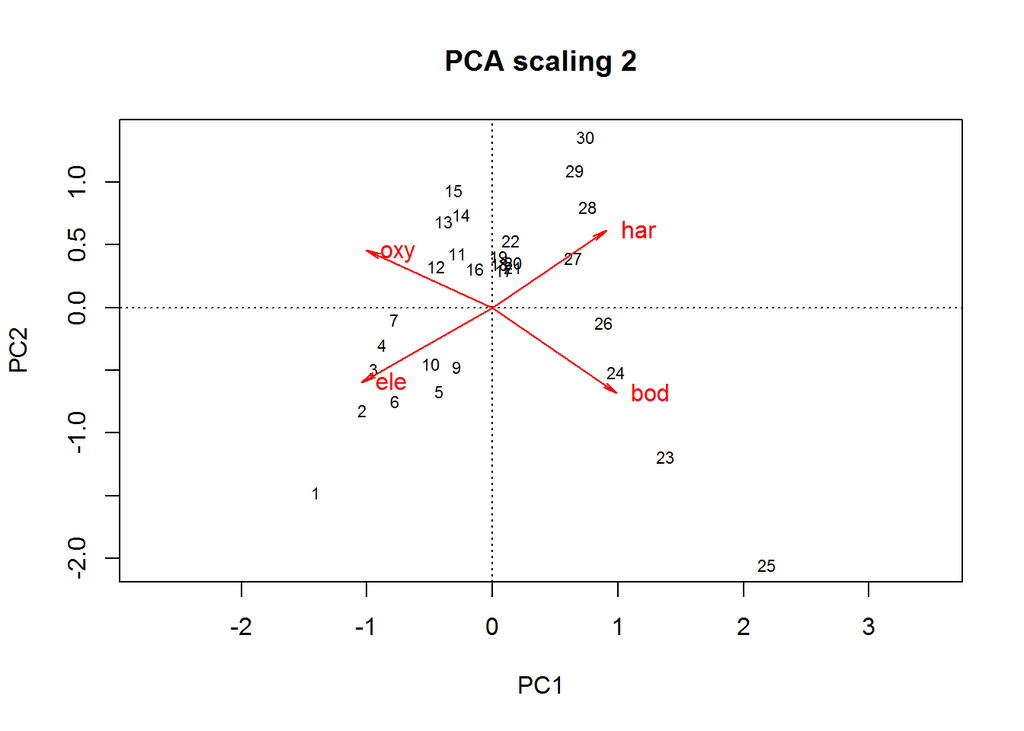

```r
# scores() https://www.rdocumentation.org/packages/vegan/versions/2.4-2/topics/scores
# 从排序结果中获取物种或者位点的分数
var.sc2.sub <- scores(env.pca,
                      display = "species")[c(2, 6, 10, 11), ]
biplot(env.pca,
       type = "n",
       main = "PCA scaling 2")
text(env.pca,
     scaling = 2,
     display = "sites",
     cex = 0.7)
arrows(
  0,
  0,
  var.sc2.sub[, 1],
  var.sc2.sub[, 2],
  length = 0.10,
  angle = 10,
  col = "red"
  )
text(
  var.sc2.sub[, 1],
  var.sc2.sub[, 2],
  labels = rownames(var.sc2.sub),
  col = "red",
  pos = 4 # 下左上右 - 1,2,3,4
  )
```

```r
# 也可使用 分析包 BiodiversityR 中的 PCAsignificance() 函数展示 "broken stick model" 的结果
library(BiodiversityR)
PCAsignificance(env.pca)
```

```
##                                           1         2         3          4
## eigenvalue                         6.097948  2.167241  1.037605  0.7035255
## percentage of variance            55.435895 19.702193  9.432773  6.3956861
## cumulative percentage of variance 55.435895 75.138088 84.570861 90.9665474
## broken-stick percentage           27.453430 18.362521 13.817067 10.7867637
## broken-stick cumulative %         27.453430 45.815952 59.633018 70.4197822
## % > bs%                            1.000000  1.000000  0.000000  0.0000000
## cum% > bs cum%                     1.000000  1.000000  1.000000  1.0000000
##                                            5          6          7
## eigenvalue                         0.3517376  0.3191247  0.1645298
## percentage of variance             3.1976142  2.9011332  1.4957257
## cumulative percentage of variance 94.1641616 97.0652948 98.5610205
## broken-stick percentage            8.5140365  6.6958547  5.1807031
## broken-stick cumulative %         78.9338187 85.6296734 90.8103765
## % > bs%                            0.0000000  0.0000000  0.0000000
## cum% > bs cum%                     1.0000000  1.0000000  1.0000000
##                                            8
## eigenvalue                         0.1117273
## percentage of variance             1.0157029
## cumulative percentage of variance 99.5767234
## broken-stick percentage            3.8820018
## broken-stick cumulative %         94.6923783
## % > bs%                            0.0000000
## cum% > bs cum%                     1.0000000
```

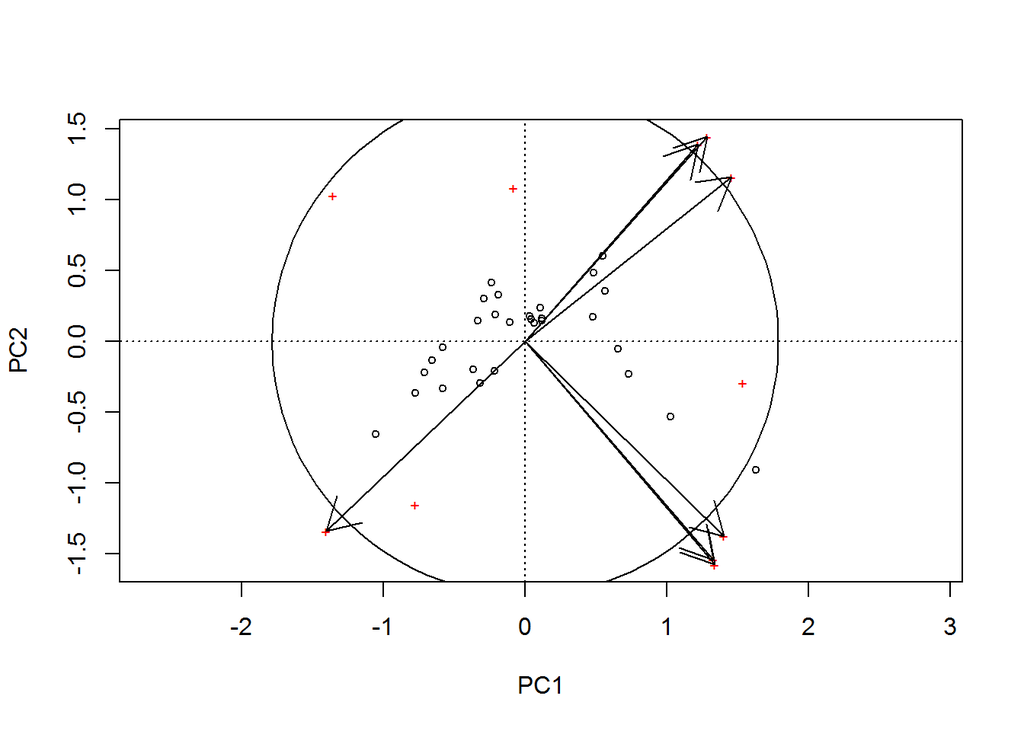

```
## $radius
## [1] 1.786308
##
## $constant
## [1] 4.189264
```

```r
# https://www.rdocumentation.org/packages/vegan/versions/2.3-5/topics/ordiplot
plot1 <- ordiplot(env.pca, choices=c(1,2), scaling=1)
ordiequilibriumcircle(env.pca, plot1)
```

#### 5.3.2.4 将补充**向量**投影到 PCA 的双序图(Biplot)

使用 predict() 函数将补充向量添加到 PCA 结果中(**预测新向量在 PCA 结果中的位置**). 该函数使用排序结果计算新向量的排序得分. 含有补充向量的数据框中必须具有原始数据集中相同的 *行名*.

**分析包 vegan 中的 predict() 函数**

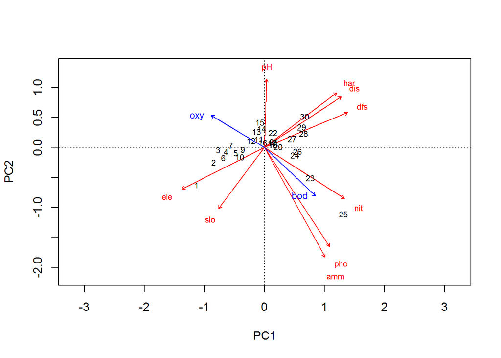

```r
# 剔除两个环境变量的的信息
env.pca2 <- rda(env[, -c(10, 11)],
                scale = TRUE # 进行分析之前应将变量缩放 | 数据变换
                )
new.var <- env[, c(10, 11)]
# 计算新变量箭头的位置? (arrow tips)
new.vscores <- predict(env.pca2, # 模型预测
                       type = "sp",
                       newdata = new.var,
                       scaling = 2) # ??
biplot(env.pca2, scaling = 1)
arrows(
  0,
  0,
  new.vscores[, 1],
  new.vscores[, 2],
  length = 0.05,
  angle = 30,
  col = "blue"
  )
text(
  new.vscores[, 1],
  new.vscores[, 2],
  labels = rownames(new.vscores),
  cex = 0.8,
  col = "blue",
  pos = 2 # 下左上右 - 1,2,3,4
  )
```

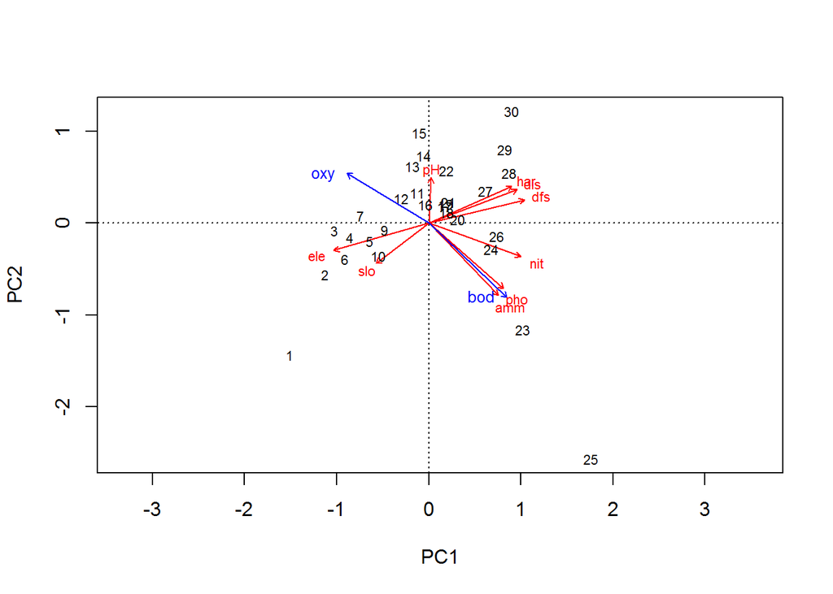

```r
biplot(env.pca2, scaling = 2)
arrows(
  0,
  0,
  new.vscores[, 1],
  new.vscores[, 2],
  length = 0.05,
  angle = 30,
  col = "blue"
  )
text(
  new.vscores[, 1],
  new.vscores[, 2],
  labels = rownames(new.vscores),
  cex = 0.8,
  col = "blue",
  pos = 2 # 下左上右 - 1,2,3,4
  )
```

> 补充向量在进行 predict() 分析之前的数据处理, 必须与原始数据集的处理过程相一致.

#### 5.3.2.5 将补充**对象**投影到 PCA 的双序图(Biplot)

使用 predict() 函数将补充**对象**添加到 PCA 结果中(**预测新对象在 PCA 结果中的位置**).

**分析包 stats 中的 predict() 函数**

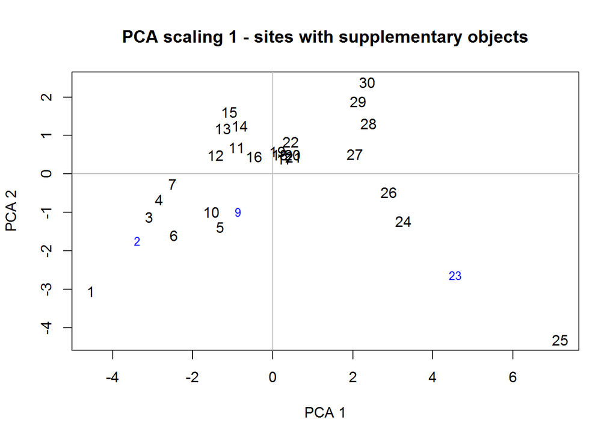

```r
# 使用 prcomp() 计算 PCA
# https://www.rdocumentation.org/packages/stats/versions/3.6.0/topics/prcomp
env.prcomp <- prcomp(env[-c(2, 8, 22), ], # 环境变量矩阵
                     scale. = TRUE # 进行分析之前应将变量缩放 | 数据变换
                     )

# 使用 biplot.prcomp() 可视化
# biplot(env.prcomp, scale = 0)
# 使用 plot() 绘制 PCA 位点分数
plot(
  env.prcomp$x[ ,1],
  env.prcomp$x[ ,2],
  type = "n", # 不立即绘制图形
  main = "PCA scaling 1 - sites with supplementary objects",
  xlab = "PCA 1",
  ylab = "PCA 2"
  )
abline(h = 0, col = "gray")
abline(v = 0, col = "gray")
text(
  env.prcomp$x[ ,1],
  env.prcomp$x[ ,2],
  labels = rownames(env[-c(2, 8, 22), ])
  )

# 预测新的位点分数
new.sit <- env[c(2, 8, 22), ]
pca.newsit <- predict(env.prcomp,
                      new.sit)
# 将位点得分映射到 PCA 绘图中
text(
   pca.newsit[, 1],
   pca.newsit[, 2],
   labels = rownames(pca.newsit),
   cex = 0.8,
   col = "blue"
   )
```

- **非本书中的示例** >>>

```r
# 使用 vegan 分析包中的 rda() 计算 PCA
env.small <- env[-c(2, 8, 22), ]
env.pca3 <- rda(env.small,
                scale = TRUE) # 进行分析之前应将变量缩放 | 数据变换
new.sit <- env[c(2, 8, 22), ]
# 计算位点得分
# 提取相关的矩阵结果
U.mat <- env.pca3$CA$v
# 处理数据
env.mean <- apply(env.small, # 输入数据
                  2, # 列方向
                  mean) # 均值计算
env.sd <- apply(env.small,
                2, # 列方向
                sd) # 标准差计算
# scale https://www.rdocumentation.org/packages/base/versions/3.6.0/topics/scale
# 矩阵对象的列进行缩放与居中
newsit.stand <- scale(new.sit,
                      center = env.mean,
                      scale = env.sd)
# Raw scaling 1 scores of new sites
(newsit.scores <- newsit.stand %*% U.mat)
```

```
##           PC1        PC2       PC3        PC4        PC5        PC6
## 2  -3.3898490 -1.7420473 0.4713602 -0.4730351 -0.6757162  1.3479973
## 9  -0.8723273 -0.9821944 0.4183420 -1.2423014 -0.8314606 -0.3583726
## 23  4.5508141 -2.6343115 1.2211512  0.1497109 -0.1196445 -0.7326481
##           PC7        PC8         PC9        PC10        PC11
## 2  -1.2694460  0.1307125 -0.07681705  0.20823041  0.09997897
## 9   0.6771887  0.7530679  0.13470656  0.17538067  0.15220152
## 23  0.2626282 -1.1049493 -0.41172024 -0.06127545 -0.27403090
```

```r
# 提取 vegan 结果对象中的位点分数
# scores() https://www.rdocumentation.org/packages/vegan/versions/2.4-2/topics/scores
# 从排序结果中获取物种或者位点的分数
env.scores1 <- scores(
  env.pca,
  display = "sites",
  choices = c(1, 2),
  scaling = 1
  )
const <- attributes(env.scores1)$const # 获取对象属性列表
# 计算位点得分
(newsit.scores.cons <- newsit.scores / const)
```

```
##           PC1        PC2        PC3        PC4         PC5         PC6
## 2  -0.8091754 -0.4158362 0.11251624 -0.1129161 -0.16129714  0.32177428
## 9  -0.2082293 -0.2344551 0.09986051 -0.2965441 -0.19847417 -0.08554548
## 23  1.0863041 -0.6288245 0.29149543  0.0357368 -0.02855978 -0.17488708
##            PC7         PC8         PC9        PC10        PC11
## 2  -0.30302366  0.03120178 -0.01833665  0.04970573  0.02386552
## 9   0.16164863  0.17976141  0.03215519  0.04186432  0.03633133
## 23  0.06269078 -0.26375741 -0.09827986 -0.01462678 -0.06541267
```

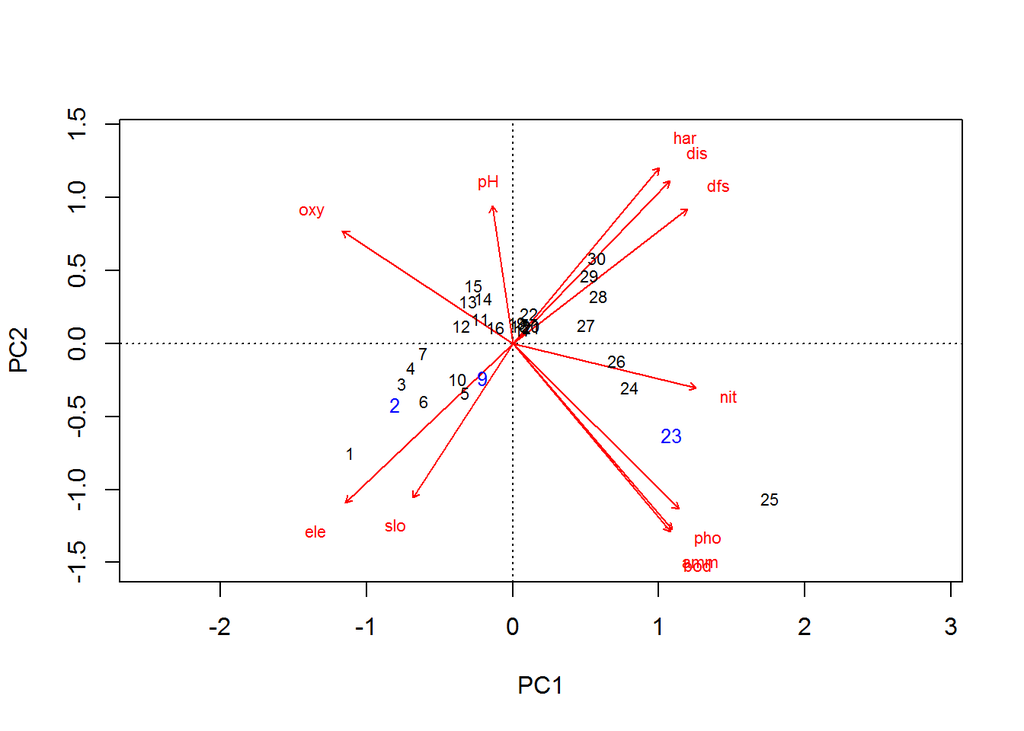

```r
biplot(env.pca3,
       scaling = 1) # distance biplot
text(
  newsit.scores.cons[, 1],
  newsit.scores.cons[, 2],
  labels = rownames(newsit.scores.cons),
  cex = 0.8,
  col = "blue"
  )
```

```r
# 手动计算 vegan 常量 (constant)
n <- nrow(env[-c(2, 8, 22), ])
eigenv <- env.pca3$CA$eig
tot <- sum(eigenv)
(const <- ((n - 1) * tot) ^ 0.25)
```

```
## [1] 4.072238
```

- <<< **上述示例非本书**

#### 5.3.2.6 比较聚类和排序的结果

比较聚类分析结果和排序分析结果可助于确定位点分组中的差异. 有两种方式可用于整合聚类分析结果和排序分析结果: 1> 排序结果中使用不同的颜色区分位点的簇, 2> 在原有图形展示的基础上叠加 **树形图**.

```r
# 使用环境数据集聚类分析: 标准化变量之后计算 Euclidean 距离, 然后进行 ward 最小方差聚类分析
env.w <- hclust(dist(scale(env)), "ward.D")
# 将树形图切分成 4 组
gr <- cutree(env.w, k = 4)
(grl <- levels(factor(gr))) # 注意观察结果的呈现形式, 与 factor(gr) 进行对比
```

```
## [1] "1" "2" "3" "4"
```

```r
factor(gr)
```

```
##  1  2  3  4  5  6  7  9 10 11 12 13 14 15 16 17 18 19 20 21 22 23 24 25 26
##  1  1  1  1  1  1  1  1  1  2  1  2  2  2  2  2  2  2  2  2  2  3  3  3  3
## 27 28 29 30
##  4  4  4  4
## Levels: 1 2 3 4
```

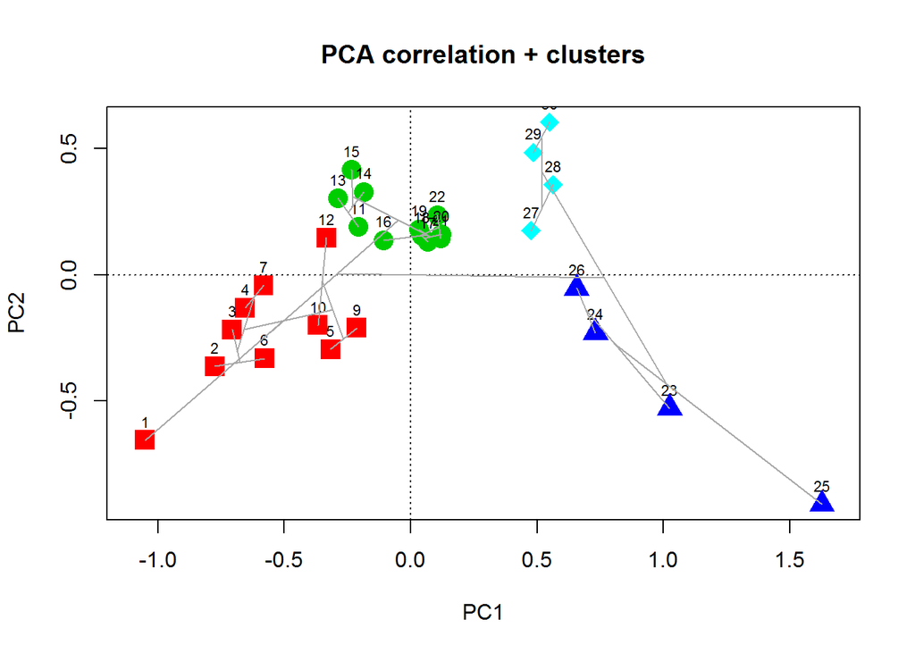

```r
# 提取位点信息, scaling 1
sit.sc1 <- scores(env.pca,
                  display = "wa",
                  scaling = 1)

# 使用类群标识符和颜色绘制 (scaling 1)
p <- plot(
  env.pca,
  display = "wa",
  scaling = 1,
  type = "n",
  main = "PCA correlation + clusters"
)
abline(v = 0, lty = "dotted")
abline(h = 0, lty = "dotted")
for (i in 1:length(grl)) {
  points(sit.sc1[gr == i, ],
         pch = (14 + i),
         cex = 2,
         col = i + 1)
  }
text(sit.sc1,
     row.names(env),
     cex = 0.7,
     pos = 3) # 上左下右 - 1,2,3,4
# ordicluster 添加树形图
# https://github.com/vegandevs/vegan/blob/master/R/ordicluster.R
ordicluster(p,
            env.w,
            col = "dark grey")
```

### 5.3.3 已转换的物种数据的主成分分析(PCA)

作为一种 **线性分析方法** 的 PCA 保留了位点之间的 Euclidean 距离, 因此不适用对 **物种丰度数据** 之间进行分析. 物种丰度数据经过 **转换预处理** 之后可以进行后续相应的 PCA 分析.

#### 5.3.3.1 对已 Hellinger-转换的鱼类物种数据进行主成分分析(PCA)

```r
# 物种数据进行 Hellinger 预转化
spe.h <- decostand(spe, "hellinger") # 群落类型数据的标准化
(spe.h.pca <- rda(spe.h))
```

```
## Call: rda(X = spe.h)
##
##               Inertia Rank
## Total          0.5025
## Unconstrained  0.5025   27
## Inertia is variance
##
## Eigenvalues for unconstrained axes:
##     PC1     PC2     PC3     PC4     PC5     PC6     PC7     PC8
## 0.25796 0.06424 0.04632 0.03850 0.02197 0.01675 0.01472 0.01156
## (Showing 8 of 27 unconstrained eigenvalues)
```

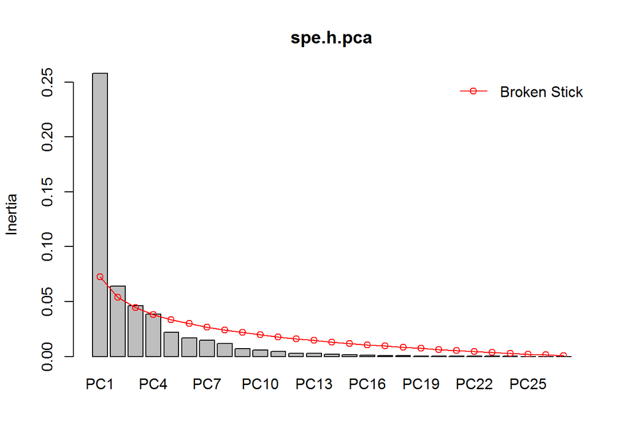

```r
# 绘制与主成分数量的差异
# 碎石图和破碎棒模型
screeplot(spe.h.pca,
  bstick = TRUE,
  npcs = length(spe.h.pca$CA$eig)
  )
```

```r
# PCA biplots 双序图
(spe.pca.sc1 <- scores(spe.h.pca,
                      display = "species",
                      scaling = 1) ) # 注意参数 scaling ?????
```

```
##             PC1         PC2
## Cogo  0.2419541  0.23200616
## Satr  0.9052566  0.03250281
## Phph  0.7231128  0.41317186
## Babl  0.5388341  0.46470670
## Thth  0.2357742  0.17546656
## Teso  0.1086662  0.40957273
## Chna -0.2580780  0.13707039
## Pato -0.2043890  0.49879855
## Lele -0.1596077  0.43835272
## Sqce -0.1351353 -0.43208101
## Baba -0.2767206  0.59322911
## Albi -0.2468841  0.45449863
## Gogo -0.3229361  0.27359596
## Eslu -0.2111620  0.35810494
## Pefl -0.2193851  0.50746068
## Rham -0.3189576  0.38791069
## Legi -0.3180820  0.23019433
## Scer -0.2682658  0.08642038
## Cyca -0.2609903  0.37444773
## Titi -0.2675479  0.43963461
## Abbr -0.2815757  0.24630882
## Icme -0.2054031  0.16303703
## Gyce -0.4208738 -0.04993437
## Ruru -0.4919202 -0.39369530
## Blbj -0.3393938  0.10290401
## Alal -0.5936785 -0.73150392
## Anan -0.2879483  0.33252031
## attr(,"const")
## [1] 1.93676
```

```r
(spe.pca.sc2 <- scores(spe.h.pca,
                      display = "species",
                      scaling = 2) ) # 注意参数 scaling ?????
```

```
##              PC1         PC2
## Cogo  0.17335527  0.08295314
## Satr  0.64859835  0.01162129
## Phph  0.51809591  0.14772841
## Babl  0.38606389  0.16615455
## Thth  0.16892752  0.06273757
## Teso  0.07785717  0.14644156
## Chna -0.18490773  0.04900913
## Pato -0.14644066  0.17834399
## Lele -0.11435572  0.15673176
## Sqce -0.09682176 -0.15448933
## Baba -0.19826483  0.21210737
## Albi -0.17688757  0.16250468
## Gogo -0.23137729  0.09782345
## Eslu -0.15129334  0.12803940
## Pefl -0.15718509  0.18144111
## Rham -0.22852676  0.13869636
## Legi -0.22789943  0.08230532
## Scer -0.19220708  0.03089936
## Cyca -0.18699435  0.13388271
## Titi -0.19169273  0.15719010
## Abbr -0.20174335  0.08806701
## Icme -0.14716722  0.05829342
## Gyce -0.30154770 -0.01785389
## Ruru -0.35245105 -0.14076463
## Blbj -0.24316894  0.03679303
## Alal -0.42535885 -0.26154713
## Anan -0.20630920  0.11889169
## attr(,"const")
## [1] 1.93676
```

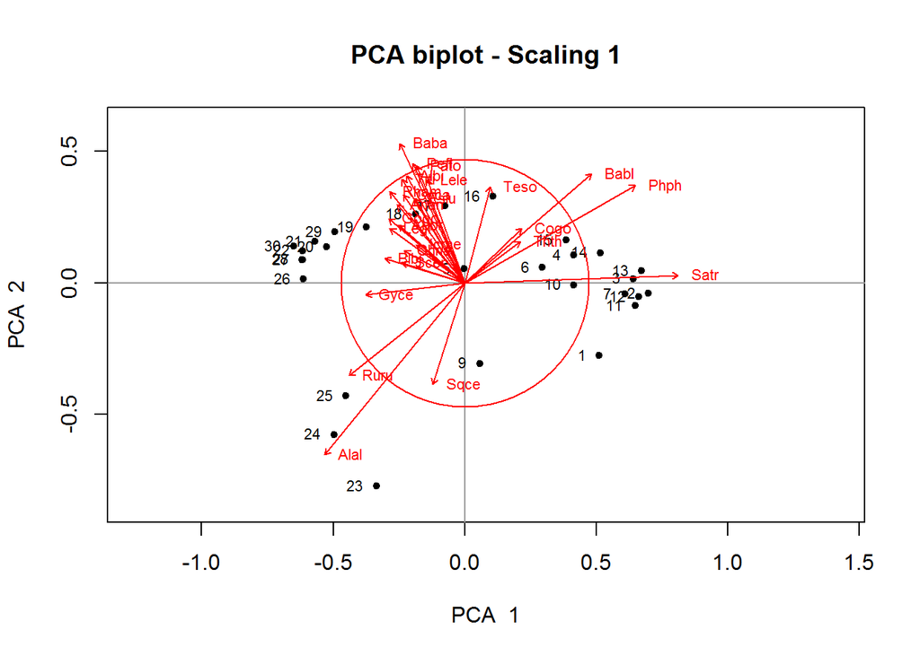

```r
# https://stackoverflow.com/questions/37128140/correlation-biplot-scaling-2-and-distance-biplot-scaling-1-pca-not-in-the-ri
# 绘制 triplot 三序图 ?
# par(mfrow = c(1, 2))
cleanplot.pca(spe.h.pca,
              scaling = 1, # distance | 群落结构 - 簇 - 距离的远近 - 梯度结构
              mar.percent = 0.06)
```

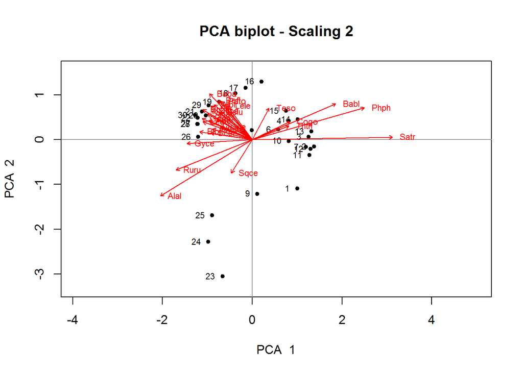

```r
cleanplot.pca(spe.h.pca,
              scaling = 2, # correlationship
              mar.percent = 0.06)
```

- 技术提示: chi-square transformation 可以用于对物种数据的前处理

> 比较分析与 **无数据转换处理的原始数据** 的 PCA 分析结果的差异

```r
(spe.pca <- rda(spe))
```

```
## Call: rda(X = spe)
##
##               Inertia Rank
## Total           68.96
## Unconstrained   68.96   27
## Inertia is variance
##
## Eigenvalues for unconstrained axes:
##   PC1   PC2   PC3   PC4   PC5   PC6   PC7   PC8
## 45.23  7.82  3.97  2.81  1.88  1.79  1.24  1.03
## (Showing 8 of 27 unconstrained eigenvalues)
```

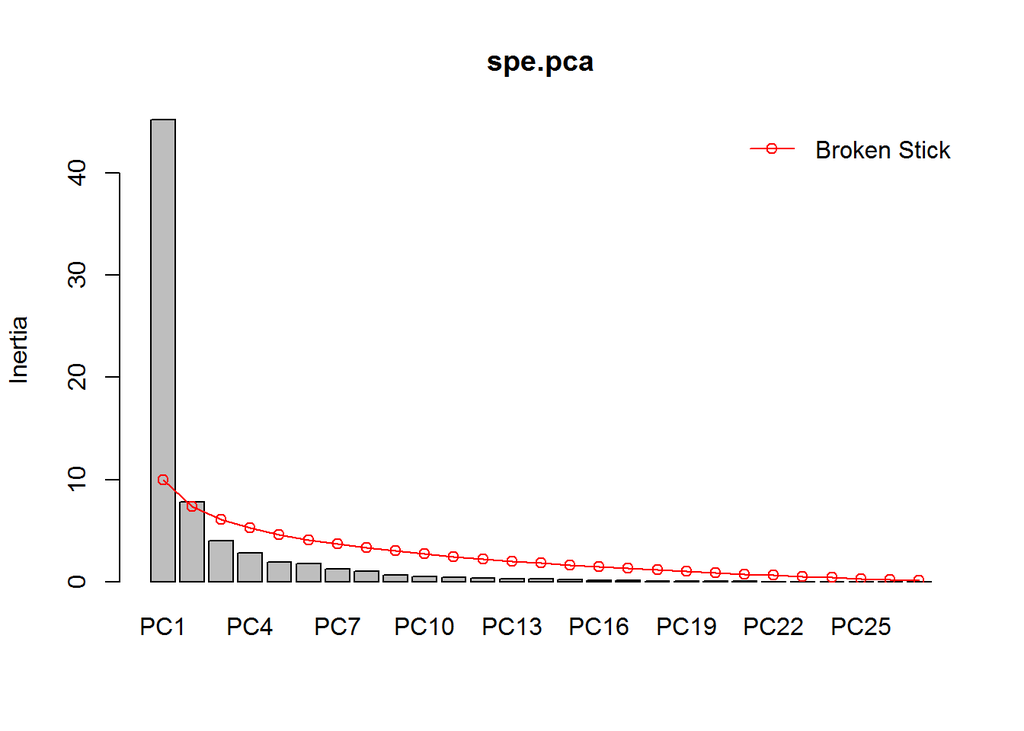

```r
# 绘制与主成分数量的差异
# 碎石图和破碎棒模型
screeplot(spe.pca,
  bstick = TRUE,
  npcs = length(spe.pca$CA$eig)
  )
```

```r
# PCA biplots 双序图
(spe.pca.sc1 <- scores(spe.pca,
                      display = "species",
                      scaling = 1) ) # 注意参数 scaling ?????
```

```
##             PC1         PC2
## Cogo  0.3822390 -1.16939020
## Satr  1.5007153 -1.91836733
## Phph  1.3839474 -2.76399480
## Babl  1.0121956 -3.03571837
## Thth  0.3313623 -0.90864114
## Teso  0.2812674 -2.04746001
## Chna -0.6853906 -0.20840219
## Pato -0.6252554 -1.71492386
## Lele -0.7282387 -1.99369782
## Sqce -0.8782523 -0.36848952
## Baba -1.4715803 -1.49474811
## Albi -0.9542524 -1.25216533
## Gogo -1.6822784 -0.89369851
## Eslu -1.2516337 -0.76889137
## Pefl -1.1644653 -1.26515329
## Rham -1.5575835 -0.57542027
## Legi -1.2969039 -0.35875960
## Scer -0.9661823 -0.15312618
## Cyca -1.2064925 -0.58005088
## Titi -1.5552786 -0.59929377
## Abbr -1.4084184 -0.21223127
## Icme -1.0834766 -0.25158654
## Gyce -1.7675751  0.44958656
## Ruru -1.9483437  0.03432143
## Blbj -1.6033225  0.04933342
## Alal -2.0136391  1.22938439
## Anan -1.3427146 -0.35745272
## attr(,"const")
## [1] 6.628755
```

```r
(spe.pca.sc2 <- scores(spe.pca,
                      display = "species",
                      scaling = 2) ) # 注意参数 scaling ?????
```

```
##             PC1         PC2
## Cogo  0.3095671 -0.39392411
## Satr  1.2153969 -0.64622668
## Phph  1.1208291 -0.93108716
## Babl  0.8197553 -1.02262073
## Thth  0.2683631 -0.30608744
## Teso  0.2277924 -0.68971321
## Chna -0.5550831 -0.07020295
## Pato -0.5063808 -0.57769413
## Lele -0.5897848 -0.67160272
## Sqce -0.7112775 -0.12413043
## Baba -1.1918011 -0.50352510
## Albi -0.7728284 -0.42180798
## Gogo -1.3624409 -0.30105382
## Eslu -1.0136711 -0.25901094
## Pefl -0.9430752 -0.42618314
## Rham -1.2614533 -0.19383771
## Legi -1.0503344 -0.12085278
## Scer -0.7824902 -0.05158252
## Cyca -0.9771122 -0.19539759
## Titi -1.2595865 -0.20187981
## Abbr -1.1406476 -0.07149283
## Icme -0.8774843 -0.08475016
## Gyce -1.4315209  0.15144901
## Ruru -1.5779215  0.01156161
## Blbj -1.2984962  0.01661859
## Alal -1.6308028  0.41413392
## Anan -1.0874355 -0.12041254
## attr(,"const")
## [1] 6.628755
```

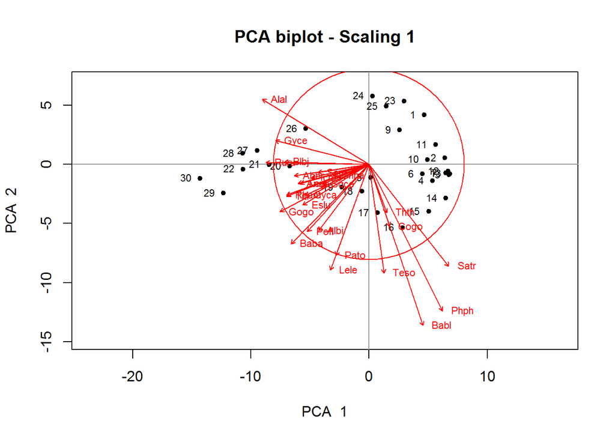

```r
# https://stackoverflow.com/questions/37128140/correlation-biplot-scaling-2-and-distance-biplot-scaling-1-pca-not-in-the-ri
# 绘制 triplot 三序图 ?
# par(mfrow = c(1, 2))
cleanplot.pca(spe.pca,
              scaling = 1, # distance
              mar.percent = 0.06)
```

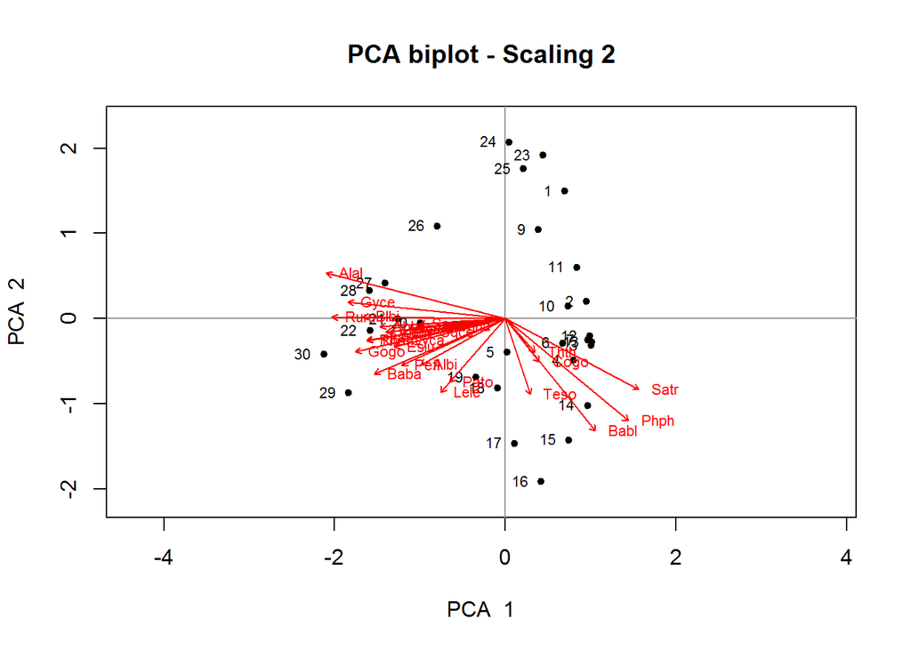

```r
cleanplot.pca(spe.pca,
              scaling = 2, # correlationship
              mar.percent = 0.06)
```

#### 5.3.3.2 使用环境变量对轴进行事后解释(Passive -‘post hoc’- Explanation)

```r
biplot(spe.h.pca, # 默认 scaling 2 | correlationship
       main = "PCA fish abundances - scaling 2")
# envfit() https://www.rdocumentation.org/packages/vegan/versions/2.4-2/topics/envfit
# 将环境变量或因子拟合到排序结果上
# envfit() 寻找 环境变量中的向量或者因子平均值
# ? 点向量的投影与相应的环境变量具有最大的相关性, 这些因子表示因子水平的平均值
# envfit() 对 环境变量 进行 置换检验, 计算 变量的 p-value
(spe.h.pca.env <- envfit(spe.h.pca,
                         env,
                         scaling = 1)) # ??
```

```
##
## ***VECTORS
##
##          PC1      PC2     r2 Pr(>r)
## dfs -0.99965  0.02643 0.7328  0.001 ***
## ele  0.98258 -0.18586 0.5889  0.001 ***
## slo  0.61597 -0.78777 0.1498  0.092 .
## dis -0.96052  0.27823 0.5368  0.001 ***
## pH   0.34684  0.93792 0.0283  0.665
## har -1.00000 -0.00061 0.2771  0.013 *
## pho -0.34979 -0.93683 0.5717  0.001 ***
## nit -0.84180 -0.53980 0.5743  0.001 ***
## amm -0.32603 -0.94536 0.5886  0.001 ***
## oxy  0.57218  0.82012 0.7707  0.001 ***
## bod -0.30537 -0.95224 0.7697  0.001 ***
## ---
## Signif. codes:  0 '***' 0.001 '**' 0.01 '*' 0.05 '.' 0.1 ' ' 1
## Permutation: free
## Number of permutations: 999
```

```r
(spe.h.pca.env <- envfit(spe.h.pca,
                         env,
                         scaling = 2)) # ??
```

```
##
## ***VECTORS
##
##          PC1      PC2     r2 Pr(>r)
## dfs -0.99991  0.01319 0.7328  0.001 ***
## ele  0.99557 -0.09397 0.5889  0.001 ***
## slo  0.84295 -0.53799 0.1498  0.078 .
## dis -0.98971  0.14306 0.5368  0.001 ***
## pH   0.59537  0.80345 0.0283  0.712
## har -1.00000 -0.00031 0.2771  0.017 *
## pho -0.59908 -0.80069 0.5717  0.002 **
## nit -0.95242 -0.30478 0.5743  0.001 ***
## amm -0.56854 -0.82266 0.5886  0.001 ***
## oxy  0.81335  0.58177 0.7707  0.001 ***
## bod -0.54061 -0.84127 0.7697  0.001 ***
## ---
## Signif. codes:  0 '***' 0.001 '**' 0.01 '*' 0.05 '.' 0.1 ' ' 1
## Permutation: free
## Number of permutations: 999
```

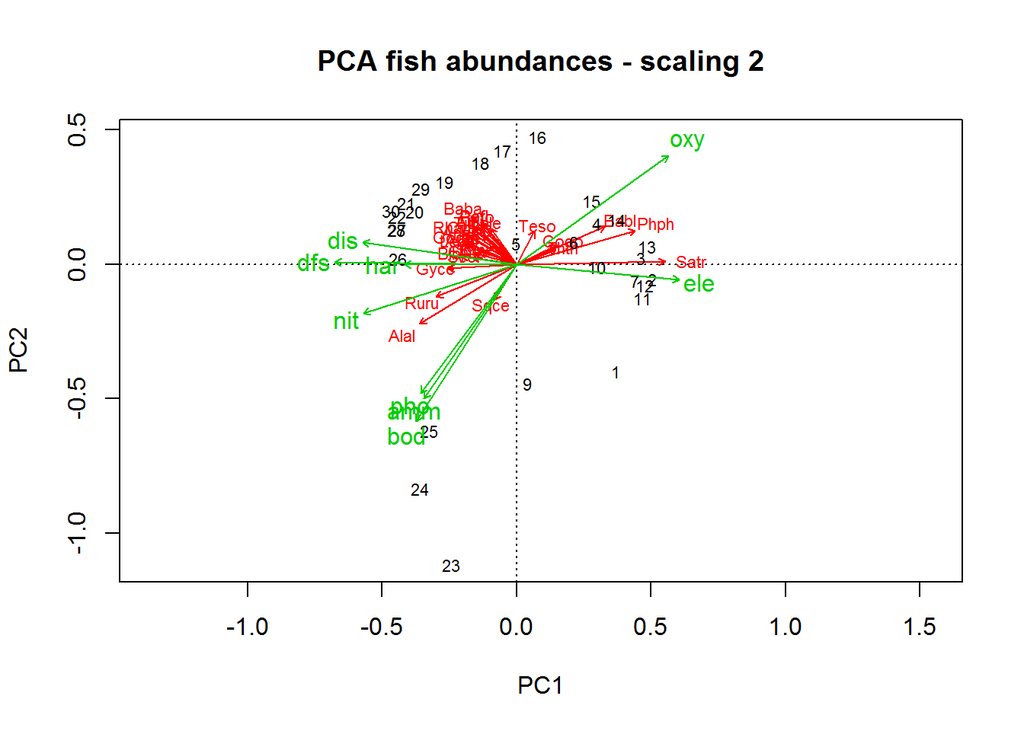

```r
# 重点突出 - 显著性的变量
plot(spe.h.pca.env, # scaling = 2 的处理结果
     p.max = 0.05,
     col = 3) # 添加显著性的环境变量
```

> 最佳方法 - 检验解释变量 - **响应变量列表** ? *第六章有所涉及*

### 5.3.4 主成分分析(PCA)的主要应用

PCA 也有很多使用限制, 比如对偏多项分布不敏感. PCA 运算的主要步骤是 **对方差矩阵(线性协方差或者相关性)进行奇异值分解 (eigen-decomposition)**, 协方差务必由 **定量数据** 计算而来.

- 输入数据类型必须是 **维度均质化的变量表** – 变量方差和 需要分解成 特征值; 只有度量相一致的变量 产生的 方差才有意义(方差的单位 – 变量单位的平方), 数据转换处理之后的变量没有 *量纲* (dimensionless).
- 不能用于计算 **转置数据矩阵** – 对象之间的协方差或者相关性 无意义
- 协方差 和 相关性 由定量变量确定 – PCA对数据精度的变化具有很强的鲁棒性
- 二元数据(有无)可应用 PCA
- 对 物种有无数据 进行 PCA 之间, 需要进行数据变换(chord, Hellinger or log-chord transformation)
- 避免错误地解释变量之间的关系 – 根据向量箭头的顶部(尖端)的近似值, 而不是它们在双序图中的角度.

### 5.3.5 使用 PCA.newr() 进行主成分分析(PCA)

本书提供了 *快速分析脚本 – PCA.newr() 和 biplot.PCA.newr()*

```r
# 使用 PCA.newr() 和 biplot.PCA.newr() 对环境数据集进行主成分分析(PCA)
# 其中, PCA 相关函数默认使用 scaling 1 -- distance biplot
# Scaling 2 - correlation biplot
(env.PCA.PL <- PCA.newr(env, stand = TRUE))
```

```
##
## Principal Component Analysis
##
## Call:
## PCA.newr(Y = env, stand = TRUE)
##
## The data have been centred and standardized
##         by column
##
## Total variance in matrix Y:  11
##
## Eigenvalues
## 6.097948 2.167241 1.037605 0.7035255 0.3517376 0.3191247 0.1645298 0.1117273 0.02313374 0.01737455 0.006052124
##
## Relative eigenvalues
## 0.554359 0.1970219 0.09432773 0.06395686 0.03197614 0.02901133 0.01495726 0.01015703 0.002103068 0.001579505 0.0005501931
##
## Cumulative relative eigenvalues
## 0.554359 0.7513809 0.8457086 0.9096655 0.9416416 0.9706529 0.9856102 0.9957672 0.9978703 0.9994498 1
```

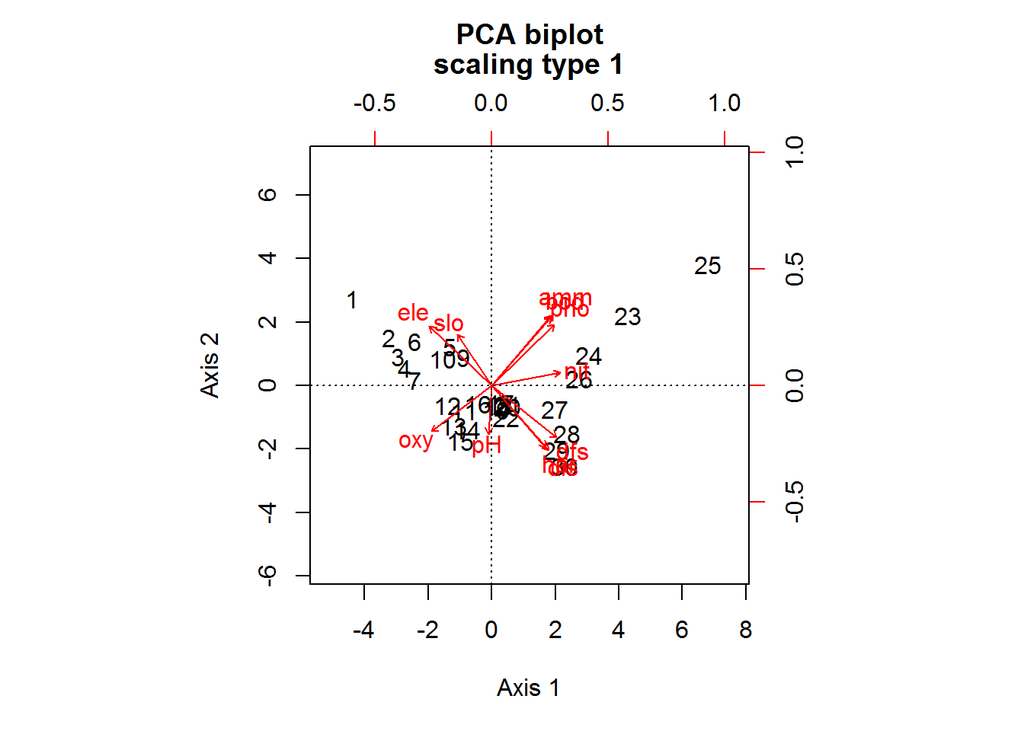

```r
biplot.PCA.newr(env.PCA.PL)
```

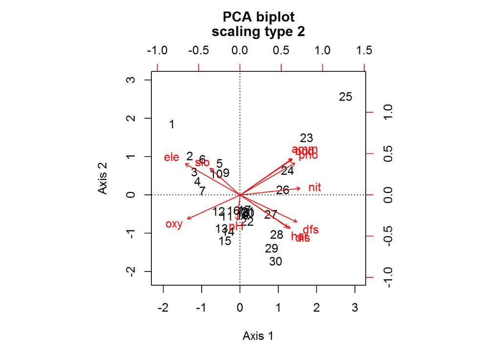

```r
biplot.PCA.newr(env.PCA.PL,
                scaling = 2) # scaling 2 -- correlation biplot
```

### 5.3.6 主成分分析中的缺省值处理

PCA 无法对 非完整数据矩阵 进行计算. **缺失值 - 估计 - 替换填充** PCA - 迭代计算 - 复杂运算可以避免 *过拟合* 和 *方差估计不足* 等问题.

```r
# 使用 NA 替换缺省值
env.miss3 <- env
env.miss3[2, 5] <- NA    # pH
env.miss3[18, 7] <- NA   # pho
env.miss3[22, 11] <- NA  # dbo

# 忽略缺省值重新
mean(env.miss3[, 5], na.rm = TRUE)
```

```
## [1] 8.05
```

```r
mean(env.miss3[, 7], na.rm = TRUE)
```

```
## [1] 0.5689286
```

```r
mean(env.miss3[, 11], na.rm = TRUE)
```

```
## [1] 4.607143
```

```r
# https://www.rdocumentation.org/packages/missMDA/versions/1.14/topics/imputePCA
# 用主成分分析模型输入数据集的缺失值
(env.imp <- imputePCA(env.miss3))
```

```
## $completeObs
##      dfs ele  slo   dis       pH har       pho  nit  amm  oxy      bod
## 1    0.3 934 48.0  0.84 7.900000  45 0.0100000 0.20 0.00 12.2  2.70000
## 2    2.2 932  3.0  1.00 7.998315  40 0.0200000 0.20 0.10 10.3  1.90000
## 3   10.2 914  3.7  1.80 8.300000  52 0.0500000 0.22 0.05 10.5  3.50000
## 4   18.5 854  3.2  2.53 8.000000  72 0.1000000 0.21 0.00 11.0  1.30000
## 5   21.5 849  2.3  2.64 8.100000  84 0.3800000 0.52 0.20  8.0  6.20000
## 6   32.4 846  3.2  2.86 7.900000  60 0.2000000 0.15 0.00 10.2  5.30000
## 7   36.8 841  6.6  4.00 8.100000  88 0.0700000 0.15 0.00 11.1  2.20000
## 9   70.5 752  1.2  4.80 8.000000  90 0.3000000 0.82 0.12  7.2  5.20000
## 10  99.0 617  9.9 10.00 7.700000  82 0.0600000 0.75 0.01 10.0  4.30000
## 11 123.4 483  4.1 19.90 8.100000  96 0.3000000 1.60 0.00 11.5  2.70000
## 12 132.4 477  1.6 20.00 7.900000  86 0.0400000 0.50 0.00 12.2  3.00000
## 13 143.6 450  2.1 21.10 8.100000  98 0.0600000 0.52 0.00 12.4  2.40000
## 14 152.2 434  1.2 21.20 8.300000  98 0.2700000 1.23 0.00 12.3  3.80000
```

[output cut: 78 more lines]

```r
env.imp$completeObs[2, 5]    # 初始值: 8.0
```

```
## [1] 7.998315
```

```r
env.imp$completeObs[18, 7]   # 初始值: 0.60
```

```
## [1] 0.3692355
```

```r
env.imp$completeObs[22, 11]  # 初始值: 16.4
```

```
## [1] 10.69139
```

```r
env.imp3 <- env.imp$completeObs
env.imp3.pca <- rda(env.imp3,
                    scale = TRUE) # 进行分析之前应将变量缩放 | 数据变换

# Procrustes analysis
# https://en.wikipedia.org/wiki/Procrustes_analysis
# https://www.rdocumentation.org/packages/vegan/versions/2.4-2/topics/procrustes
# 将配置旋转到与其他配置的最大相似性
(pca.proc <- procrustes(env.pca,
                       env.imp3.pca,
                       scaling = 1)) # scaling 1 -- distance biplot ??
```

```
##
## Call:
## procrustes(X = env.pca, Y = env.imp3.pca, scaling = 1)
##
## Procrustes sum of squares:
## 0.0277
```

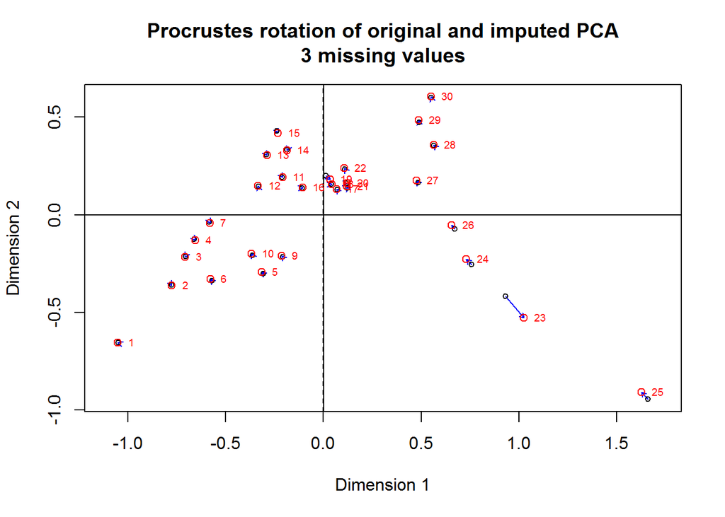

```r
# 通过可视化分析 真实数据 PCA 结果 与 推算数据 PCA 结果 的差异
plot(pca.proc,
     main = "Procrustes rotation of original and imputed PCA\n3 missing values")
points(pca.proc, display = "target", col = "red")
text(
  pca.proc,
  display = "target",
  col = "red",
  pos = 4,
  cex = 0.6
  )
```

```r
# 缺省值随机替换
rnd <- matrix(sample(c(rep(1, 32), rep(0, 287))), 29, 11)
env.miss32 <- env
env.miss32[rnd == 1] <- NA
# 统计每个变量的缺省值数量(位点方向)
summary(t(env.miss32))
```

```
##        1               2                3                 4
##  Min.   : 0.01   Min.   :  0.02   Min.   :  0.050   Min.   : 0.00
##  1st Qu.: 0.30   1st Qu.:  0.40   1st Qu.:  0.615   1st Qu.: 0.21
##  Median : 2.70   Median :  2.05   Median :  3.600   Median : 2.53
##  Mean   :13.02   Mean   : 95.87   Mean   : 99.412   Mean   :10.93
##  3rd Qu.:12.20   3rd Qu.:  6.75   3rd Qu.:  9.950   3rd Qu.: 8.00
##  Max.   :48.00   Max.   :932.00   Max.   :914.000   Max.   :72.00
##  NA's   :2       NA's   :1        NA's   :1         NA's   :2
##        5                 6                7                9
##  Min.   :  0.200   Min.   :  0.00   Min.   :  0.00   Min.   : 0.12
##  1st Qu.:  2.385   1st Qu.:  1.53   1st Qu.:  2.65   1st Qu.: 0.82
##  Median :  7.100   Median :  5.30   Median :  7.35   Median : 4.80
##  Mean   : 98.246   Mean   : 88.02   Mean   : 99.80   Mean   :20.02
##  3rd Qu.: 18.150   3rd Qu.: 21.30   3rd Qu.: 30.38   3rd Qu.: 7.20
##  Max.   :849.000   Max.   :846.00   Max.   :841.00   Max.   :90.00
##  NA's   :1                          NA's   :1        NA's   :2
##        10                11               12               13
##  Min.   :  0.010   Min.   :  0.00   Min.   :  0.00   Min.   :  0.00
##  1st Qu.:  2.525   1st Qu.:  2.70   1st Qu.:  1.05   1st Qu.:  0.52
##  Median :  9.900   Median :  8.10   Median :  7.90   Median :  2.40
##  Mean   : 76.429   Mean   : 72.56   Mean   : 67.33   Mean   : 31.13
##  3rd Qu.: 46.000   3rd Qu.: 19.90   3rd Qu.: 53.00   3rd Qu.: 21.10
##  Max.   :617.000   Max.   :483.00   Max.   :477.00   Max.   :143.60
##                    NA's   :2                         NA's   :2
##        14                15               16               17
##  Min.   :  0.000   Min.   :  0.00   Min.   :  2.00   Min.   :  0.20
##  1st Qu.:  1.215   1st Qu.:  1.00   1st Qu.:  2.70   1st Qu.:  1.50
##  Median :  8.300   Median :  8.60   Median : 10.30   Median :  8.00
##  Mean   : 66.591   Mean   : 60.87   Mean   : 76.67   Mean   : 62.73
##  3rd Qu.: 59.600   3rd Qu.: 23.00   3rd Qu.: 88.00   3rd Qu.: 58.15
##  Max.   :434.000   Max.   :415.00   Max.   :375.00   Max.   :349.00
##                    NA's   :2        NA's   :2
##        18               19               20               21
##  Min.   :  0.20   Min.   :  0.15   Min.   :  0.30   Min.   :  0.20
##  1st Qu.:  1.50   1st Qu.:  1.00   1st Qu.:  1.80   1st Qu.:  2.20
##  Median :  8.00   Median :  5.70   Median :  8.00   Median :  7.90
##  Mean   : 62.16   Mean   : 44.53   Mean   : 61.09   Mean   : 72.61
##  3rd Qu.: 57.50   3rd Qu.: 22.07   3rd Qu.: 56.40   3rd Qu.: 85.00
##  Max.   :333.00   Max.   :310.00   Max.   :286.00   Max.   :282.10
##                   NA's   :1                         NA's   :2
```

[output cut: 9 more lines]

```
##  Min.   :  0.30   Min.   :  0.26   Min.   :  0.30   Min.   :  0.100
##  1st Qu.:  3.80   1st Qu.:  1.65   1st Qu.:  2.37   1st Qu.:  0.855
##  Median :  8.40   Median :  6.75   Median :  8.10   Median :  6.000
##  Mean   : 73.17   Mean   : 64.54   Mean   : 69.01   Mean   : 69.647
##  3rd Qu.: 80.28   3rd Qu.: 31.73   3rd Qu.: 71.60   3rd Qu.: 53.025
##  Max.   :356.90   Max.   :373.20   Max.   :394.70   Max.   :422.000
##  NA's   :1        NA's   :1                         NA's   :1
##        30
##  Min.   :  0.200
##  1st Qu.:  1.363
##  Median :  6.300
##  Mean   : 45.631
##  3rd Qu.: 79.000
##  Max.   :172.000
##  NA's   :3
```

```r
# 统计的替代方法
sapply(as.data.frame(t(env.miss32)), function(x) sum(is.na(x)))
```

```
##  1  2  3  4  5  6  7  9 10 11 12 13 14 15 16 17 18 19 20 21 22 23 24 25 26
##  2  1  1  2  1  0  1  2  0  2  0  2  0  2  2  0  0  1  0  2  1  1  2  1  1
## 27 28 29 30
##  1  0  1  3
```

```r
(env.imp2 <- imputePCA(env.miss32))
```

```
## $completeObs
##          dfs       ele          slo      dis       pH       har        pho
## 1    0.30000 1199.7747 48.000000000  0.84000 7.900000  45.00000  0.0100000
## 2    2.20000  932.0000  3.000000000  1.00000 8.000000  71.43400  0.0200000
## 3   49.92860  914.0000  3.700000000  1.80000 8.300000  52.00000  0.0500000
## 4   87.80672  697.3856  3.200000000  2.53000 8.000000  72.00000  0.1000000
## 5   21.50000  849.0000  2.300000000  2.64000 8.100000  84.00000  0.4533265
## 6   32.40000  846.0000  3.200000000  2.86000 7.900000  60.00000  0.2000000
## 7   36.80000  841.0000  6.600000000  4.00000 8.100000  88.00000 -0.1506336
## 9   70.50000  569.0623  1.200000000  4.80000 8.030580  90.00000  0.3000000
## 10  99.00000  617.0000  9.900000000 10.00000 7.700000  82.00000  0.0600000
## 11 123.40000  483.0000  4.100000000 19.90000 8.100000  83.80009  0.3000000
## 12 132.40000  477.0000  1.600000000 20.00000 7.900000  86.00000  0.0400000
## 13 143.60000  468.1329  2.100000000 21.10000 8.115707  98.00000  0.0600000
## 14 152.20000  434.0000  1.200000000 21.20000 8.300000  98.00000  0.2700000
```

[output cut: 108 more lines]

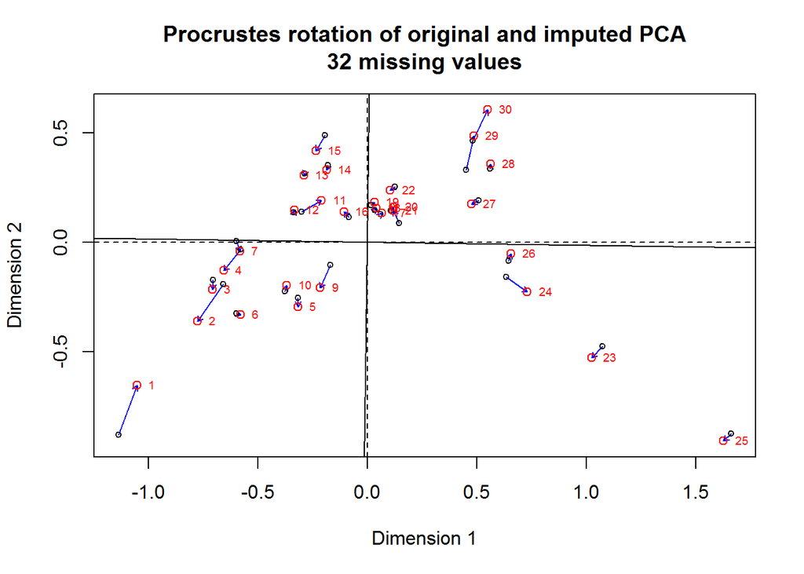

```r
env.imp32 <- env.imp2$completeObs
env.imp32.pca <- rda(env.imp32,
                     scale = TRUE) # 进行分析之前应将变量缩放 | 数据变换

# Procrustes analysis
# https://en.wikipedia.org/wiki/Procrustes_analysis
# https://www.rdocumentation.org/packages/vegan/versions/2.4-2/topics/procrustes
# 将配置旋转到与其他配置的最大相似性
pca.proc32 <- procrustes(env.pca,
                         env.imp32.pca,
                         scaling = 1) # scaling 1 -- distance biplot ??
# 通过可视化分析 真实数据 PCA 结果 与 推算数据 PCA 结果 的差异
plot(pca.proc32,
     main = "Procrustes rotation of original and imputed PCA\n32 missing values")
points(pca.proc32, display = "target", col = "red")
text(
  pca.proc32,
  display = "target",
  col = "red",
  pos = 4,
  cex = 0.6
  )
```

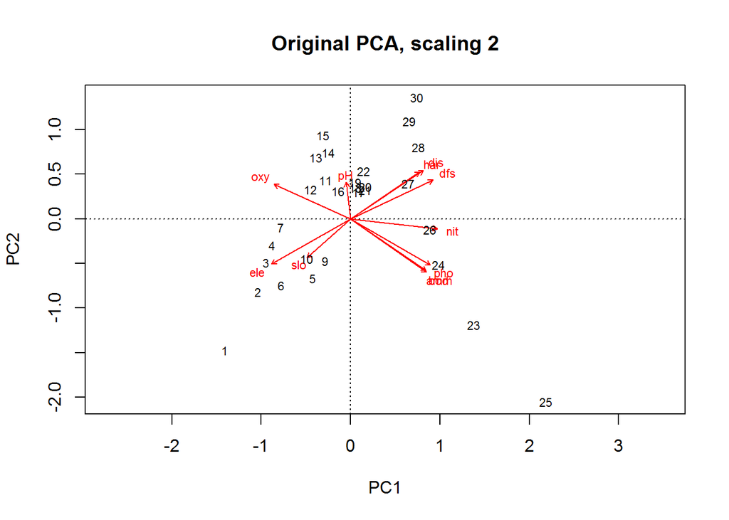

```r
# 比较分析两种不同的主成分分析结果 scaling 2
# scaling 2 -- correlation biplot
# par(mfrow = c(1, 2))
biplot(env.pca,
       main = "Original PCA, scaling 2")
```

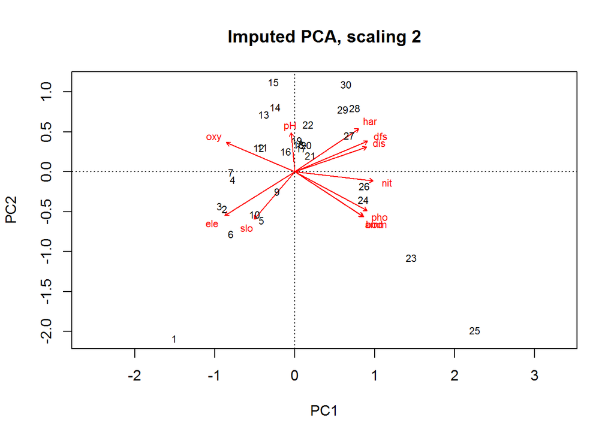

```r
biplot(env.imp32.pca,
       main = "Imputed PCA, scaling 2")
```

## 5.4 对应分析(Correspondence Analysis, CA)

### 5.4.1 简介

对应分析 – 对口 物种有无数据集 和 物种丰度数据集. 输入数据 – 非负 + 维度均质化 + 频率 或者类频率 (物种计数, 生物质, 物种有无数据集), 对于物种丰度数据可以不用经过 数据转换 直接进行对应分析. CA 计算位点之间的 χ2 距离(卡方距离, 不受双零数据的影响, 非对称的距离函数), 而非 Euclidean 距离.

原始数据转换 => Q 矩阵(描述 位点 对 Pearson χ2 统计的贡献值) => 奇异值分解(singular value decomposition) => 提取特征向量 & 特征值.

技术原因 – 由于Q矩阵计算中的频率的隐含中心, CA排序产生的一个轴小于min [n，p]. 与在PCA中一样, 正交轴按其所代表的变化的降序排列, 但不是数据的总方差, 而是通过称为总惯性的量(矩阵Q中所有值的平方和). 各个特征值总是小于1. 要知道沿轴表示的变化量, 可以将该轴的特征值除以物种数据矩阵的总惯量.

在对应分析的可视化图形中, 对象(位点 - 行) 和 物种(变量 - 列) 都是 **点 - 表示**.

- CA scaling 1: 行(位点) 位于 列(物种)的质心 – 对位点(行方向, 对象)的排序分析 非常适合. 多维空间中, 卡方距离(χ2) 保留了 对象之间的距离. 1> 降维空间中 对象的距离 与 卡方距离 相类似, 相互接近的对象点具有相类似的物种相对频率; 2> 物种点 周围的对象点 – 对物种具有高贡献.
- CA scaling 2: 列(物种) 位于 行(位点)的质心 – 对物种(列方向, 变量)的排序分析 非常适合. 多维空间中, 卡方距离(χ2) 保留了 物种之间的距离. 1> 降维空间中 物种的距离 保留在 卡方距离 中, 相互接近的物种点在不同位点(对象)之间具有相类似的相对频率; 2> 对象(位点)点 周围的物种点 更有可能在同一个位点(对象)中 发现, 或者比 远处的物种点 在该对象(位点)点具有更高的频率.

*scaling 的选择 影响 特征向量的绘制, 但不影响特征值*

### 5.4.2 使用 vegan 分析包的 cca() 函数进行对应分析(CA)

#### 5.4.2.1 分析并绘制双序图(Biplots)

```r
# 对原始物种丰度数据集进行对应分析(Correspondence Analysis, CA)
(spe.ca <- cca(spe))
```

```
## Call: cca(X = spe)
##
##               Inertia Rank
## Total           1.167
## Unconstrained   1.167   26
## Inertia is scaled Chi-square
##
## Eigenvalues for unconstrained axes:
##    CA1    CA2    CA3    CA4    CA5    CA6    CA7    CA8
## 0.6010 0.1444 0.1073 0.0834 0.0516 0.0418 0.0339 0.0288
## (Showing 8 of 26 unconstrained eigenvalues)
```

```r
summary(spe.ca)  # 默认 scaling 2
```

```
##
## Call:
## cca(X = spe)
##
## Partitioning of scaled Chi-square:
##               Inertia Proportion
## Total           1.167          1
## Unconstrained   1.167          1
##
## Eigenvalues, and their contribution to the scaled Chi-square
##
## Importance of components:
##                         CA1    CA2     CA3     CA4     CA5     CA6     CA7
## Eigenvalue            0.601 0.1444 0.10729 0.08337 0.05158 0.04185 0.03389
## Proportion Explained  0.515 0.1237 0.09195 0.07145 0.04420 0.03586 0.02904
## Cumulative Proportion 0.515 0.6387 0.73069 0.80214 0.84634 0.88220 0.91124
##                           CA8     CA9     CA10     CA11     CA12     CA13
## Eigenvalue            0.02883 0.01684 0.010826 0.010142 0.007886 0.006123
## Proportion Explained  0.02470 0.01443 0.009278 0.008691 0.006758 0.005247
## Cumulative Proportion 0.93594 0.95038 0.959655 0.968346 0.975104 0.980351
##                           CA14     CA15     CA16     CA17     CA18
## Eigenvalue            0.004867 0.004606 0.003844 0.003067 0.001823
## Proportion Explained  0.004171 0.003948 0.003294 0.002629 0.001562
## Cumulative Proportion 0.984522 0.988470 0.991764 0.994393 0.995955
##                           CA19     CA20      CA21      CA22      CA23
## Eigenvalue            0.001642 0.001295 0.0008775 0.0004217 0.0002149
## Proportion Explained  0.001407 0.001110 0.0007520 0.0003614 0.0001841
## Cumulative Proportion 0.997362 0.998472 0.9992238 0.9995852 0.9997693
##                            CA24      CA25      CA26
## Eigenvalue            0.0001528 8.949e-05 2.695e-05
## Proportion Explained  0.0001309 7.669e-05 2.310e-05
## Cumulative Proportion 0.9999002 1.000e+00 1.000e+00
##
## Scaling 2 for species and site scores
## * Species are scaled proportional to eigenvalues
## * Sites are unscaled: weighted dispersion equal on all dimensions
##
##
## Species scores
##
```

[output cut: 47 more lines]

```
## 16  0.70214 -1.501167 -1.9735888  0.98502 -0.93585 -1.27168
## 17  0.28775 -0.836803 -1.2259108  0.73302 -1.57036  0.57315
## 18  0.05299 -0.647950 -0.9234228  0.35770 -0.95401  0.77738
## 19 -0.20584 -0.007252 -1.0154343  0.07041 -1.03450  0.51442
## 20 -0.57879  0.042849 -0.3660551 -0.15019 -0.61357  0.10115
## 21 -0.67320  0.038875  0.1194956  0.17256 -0.14686 -0.12018
## 22 -0.71933  0.014694  0.2204186  0.13598  0.09459 -0.02068
## 23 -0.70438  0.735398 -0.6546250 -6.61523 -2.49441 -1.73215
## 24 -0.83976  0.390120  0.5605295 -4.38864 -2.56916 -0.96702
## 25 -0.68476  0.418842 -0.2860819 -2.80336 -0.37540 -3.93791
## 26 -0.75808  0.210204  0.5894091 -0.70004 -0.01880 -0.10779
## 27 -0.75046  0.100869  0.5531191 -0.12946  0.29164  0.11280
## 28 -0.77878  0.088976  0.7379012  0.05204  0.40940  0.43236
## 29 -0.60815 -0.203235  0.5522726  0.43621  0.15010  0.25618
## 30 -0.80860 -0.019592  0.6686542  0.88136  0.52744  0.16456
```

```r
summary(spe.ca,
        scaling = 1)
```

```
##
## Call:
## cca(X = spe)
##
## Partitioning of scaled Chi-square:
##               Inertia Proportion
## Total           1.167          1
## Unconstrained   1.167          1
##
## Eigenvalues, and their contribution to the scaled Chi-square
##
## Importance of components:
##                         CA1    CA2     CA3     CA4     CA5     CA6     CA7
## Eigenvalue            0.601 0.1444 0.10729 0.08337 0.05158 0.04185 0.03389
## Proportion Explained  0.515 0.1237 0.09195 0.07145 0.04420 0.03586 0.02904
## Cumulative Proportion 0.515 0.6387 0.73069 0.80214 0.84634 0.88220 0.91124
##                           CA8     CA9     CA10     CA11     CA12     CA13
## Eigenvalue            0.02883 0.01684 0.010826 0.010142 0.007886 0.006123
## Proportion Explained  0.02470 0.01443 0.009278 0.008691 0.006758 0.005247
## Cumulative Proportion 0.93594 0.95038 0.959655 0.968346 0.975104 0.980351
##                           CA14     CA15     CA16     CA17     CA18
## Eigenvalue            0.004867 0.004606 0.003844 0.003067 0.001823
## Proportion Explained  0.004171 0.003948 0.003294 0.002629 0.001562
## Cumulative Proportion 0.984522 0.988470 0.991764 0.994393 0.995955
##                           CA19     CA20      CA21      CA22      CA23
## Eigenvalue            0.001642 0.001295 0.0008775 0.0004217 0.0002149
## Proportion Explained  0.001407 0.001110 0.0007520 0.0003614 0.0001841
## Cumulative Proportion 0.997362 0.998472 0.9992238 0.9995852 0.9997693
##                            CA24      CA25      CA26
## Eigenvalue            0.0001528 8.949e-05 2.695e-05
## Proportion Explained  0.0001309 7.669e-05 2.310e-05
## Cumulative Proportion 0.9999002 1.000e+00 1.000e+00
##
## Scaling 1 for species and site scores
## * Sites are scaled proportional to eigenvalues
## * Species are unscaled: weighted dispersion equal on all dimensions
##
##
## Species scores
##
```

[output cut: 47 more lines]

```
## 16  0.54432 -0.570386 -0.6464636  0.284420 -0.212539 -0.26014
## 17  0.22308 -0.317953 -0.4015561  0.211655 -0.356642  0.11725
## 18  0.04108 -0.246196 -0.3024740  0.103285 -0.216664  0.15902
## 19 -0.15958 -0.002755 -0.3326130  0.020330 -0.234943  0.10523
## 20 -0.44870  0.016281 -0.1199041 -0.043366 -0.139347  0.02069
## 21 -0.52189  0.014771  0.0391417  0.049826 -0.033352 -0.02458
## 22 -0.55765  0.005583  0.0721997  0.039264  0.021482 -0.00423
## 23 -0.54606  0.279423 -0.2144273 -1.910111 -0.566501 -0.35434
## 24 -0.65102  0.148231  0.1836056 -1.267193 -0.583479 -0.19782
## 25 -0.53085  0.159144 -0.0937082 -0.809453 -0.085257 -0.80556
## 26 -0.58769  0.079869  0.1930653 -0.202133 -0.004271 -0.02205
## 27 -0.58178  0.038326  0.1811782 -0.037380  0.066234  0.02307
## 28 -0.60374  0.033808  0.2417050  0.015027  0.092978  0.08844
## 29 -0.47146 -0.077222  0.1809010  0.125954  0.034090  0.05241
## 30 -0.62686 -0.007444  0.2190226  0.254487  0.119787  0.03366
```

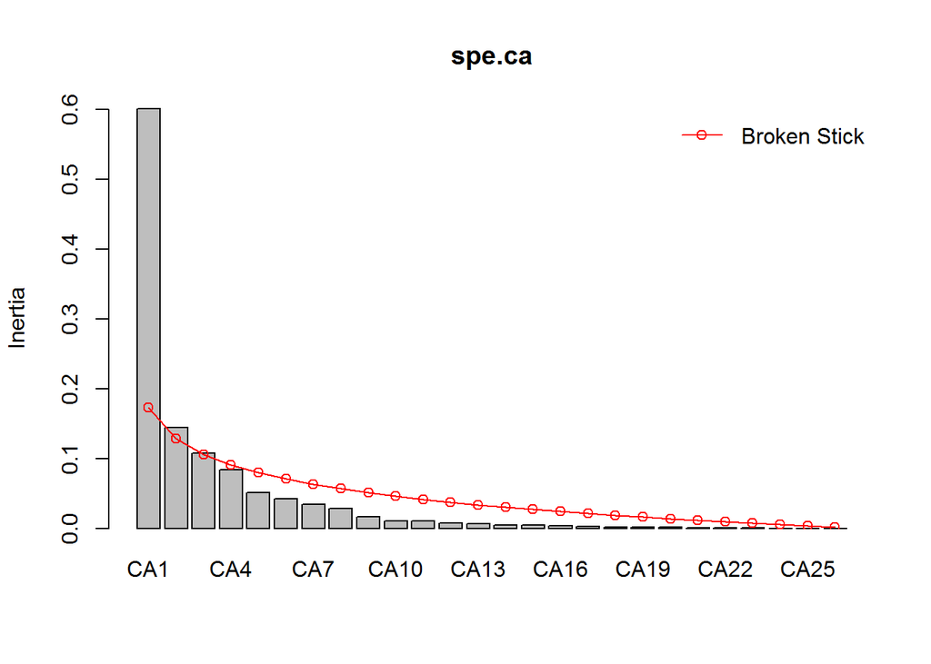

```r
# 绘制与主成分数量的差异
screeplot(spe.ca,
          bstick = TRUE, # 注意与下图进行比较
          npcs = length(spe.ca$CA$eig))
```

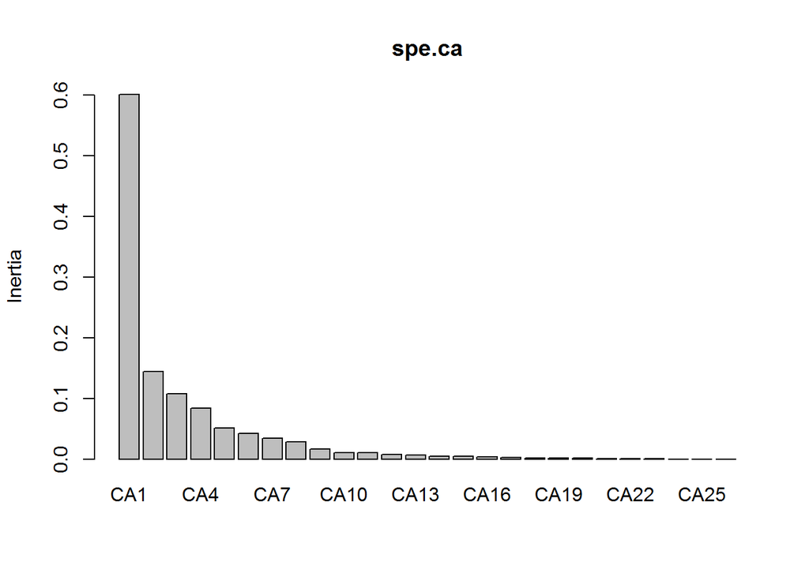

```r
screeplot(spe.ca,
          bstick = FALSE, # 注意与上图进行比较
          npcs = length(spe.ca$CA$eig))
```

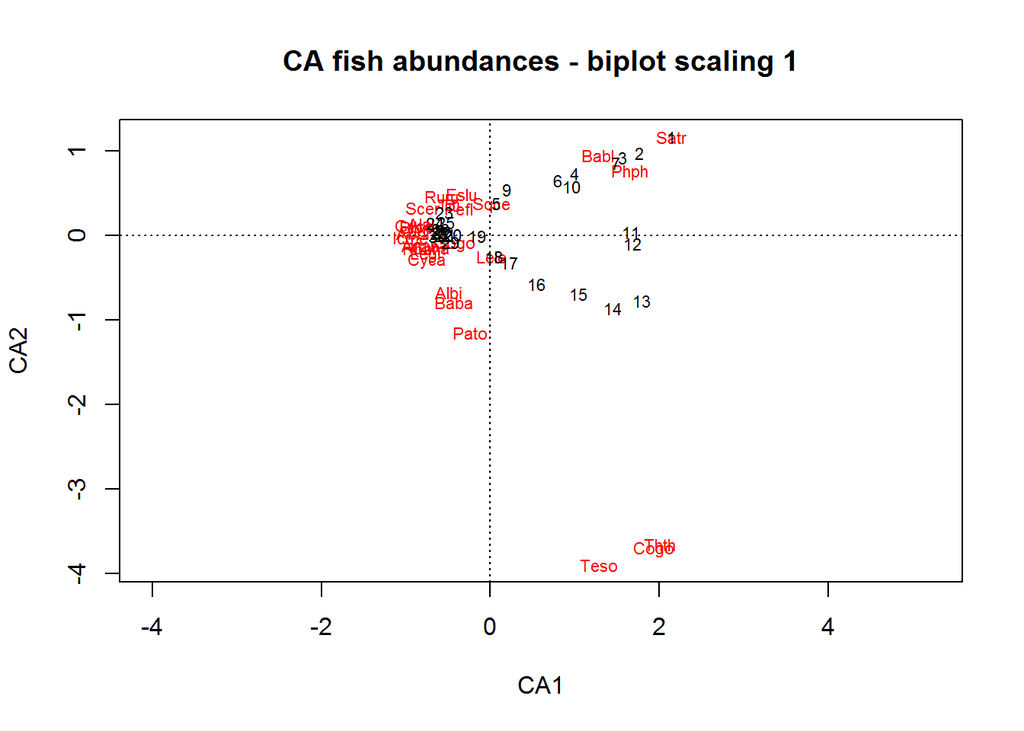

```r
# 绘制对应分析(CA)的双序图 -- biplots
# par(mfrow = c(1, 2))
# Scaling 1: sites are centroids of species
plot(spe.ca,
     scaling = 1,
     main = "CA fish abundances - biplot scaling 1"
     )
```

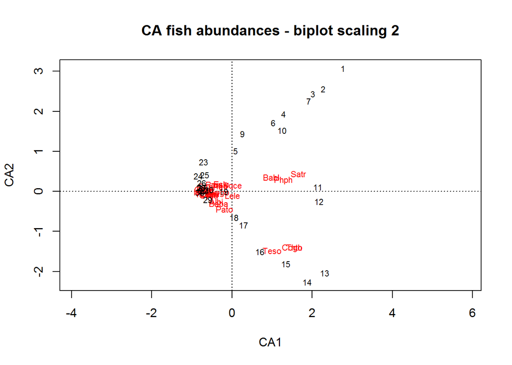

```r
# Scaling 2 (default): species are centroids of sites
plot(spe.ca,
     main = "CA fish abundances - biplot scaling 2")
```